# Ciência de Dados para Todos (Data Science For All) - 2018.2 - Análise da Produção Científica e Acadêmica da Universidade de Brasília - Engenharia Biomédica

Marcos Vinicius Prescendo Tonin, Lucas Nascimento, Carlos Aragon

20/09/2018

# Introdução

O presente trabalho tem por finalidade entender e correlacionar dados que possam algum significado mais profundo do que aparentam ter, assim com os dados da pós-graduação em engenharia Biomédica, engenharia elétrica em seus dois ramos (53001010059P8 e 53001010080P7) e engenharia de sistemas eletrônicos e de automação em mãos busca-se encontrar principais fatores, professores mais envolvidos, temas mais relevantes e afins.

# Metodologia

Para um melhor resultado do trabalho buscou-se seguir e adaptar-se a metodologia CRISP-DM, para isso baseou-se no ciclo de projeto usado pelo CRISP-DM.

O ciclo é basicamente definido pelas seguintes fases:

- **Entendimento do negócio** : primeiramente deve-se entender o que se busca encontrar, haja visto que não faz sentido fazer uma análise de dados sem saber o que se busca.
- **Entendimento dos dados** : Busca-se entender os dados de forma mais superficial primeiramente.
- **Preparação de dados** : Então limpa-se o dado e prepara o dado para que se possa facilitar seu processamento.
- **Modelagem** : Faz a modelagem do dado.
- **Avaliação** : Avalia-se o resultado da modelagem.
- **Implatação** : Faz uso dos dados.

As fases não são independentes entre si, mas possuem certa comunicação, depedendo das fases, além de não ser estritamente sequencial, sendo melhor visualizado na figura abaixo.

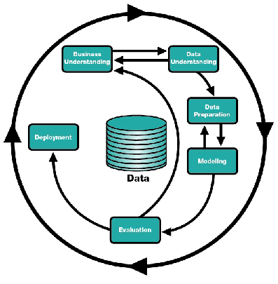

Ciclo do CRISP-DM que será usado como base

Por esta imagem consegue-se perceber que o entendimento do negócio e do dado pode muitas vezes ser alternada, indo e voltando.

## Delimitações iniciais

### domínio de Aplicação do projeto

O domínio de Aplicação do projeto é Produção Científica ou Produção Acadêmica de um subgrupo de pesquisadores vinculados é Universidade de Brasília, sendo vinculado ao subtema **engenharia Biomédica**, tais arquivos foram pegos na plataforma elattes.

### Problema abordado

Problema abordado tem por finalidade obter dados de forma descritiva, quantitativa e de modelagem computacional ou estatística, que permitam caracterizar como, porque e também para que ocorre a Produção Científica e Acadêmica na área de engenharia Biomédica.

# CRISP-DM Fase 1 - Entendimento do negócio

A Universidade de Brasília é uma das grandes universidades federais, sendo responsável pela Produção de artigos visando artigos acadêmicos, este presente trabalho de como programas :

## Programas de pós-graduação Grupo 15

| Ids | Área de Avaliação | Nome do Programa | Link Capes | ME | DO | MP |
| --- | --- | --- | --- | --- | --- | --- |
| 53001010059P8 | ENGENHARIAS IV | ENGENHARIA elétrica | [ENGENHARIA elétrica (53001010059P8)](https://sucupira.capes.gov.br/sucupira/public/consultas/coleta/programa/viewPrograma.jsf?popup=true&&cd_programa=53001010059P8) | - | - | 3 |
| 53001010080P7 | ENGENHARIAS IV | ENGENHARIA elétrica | [ENGENHARIA elétrica (53001010080P7)](https://sucupira.capes.gov.br/sucupira/public/consultas/coleta/programa/viewPrograma.jsf?popup=true&&cd_programa=53001010080P7) | 4 | 4 | - |
| 53001010081P3 | ENGENHARIAS IV | ENGENHARIA DE SISTEMAS eletrônicos E DE automação | [ENGENHARIA DE SISTEMAS eletrônicos E DE automação (53001010081P3)](https://sucupira.capes.gov.br/sucupira/public/consultas/coleta/programa/viewPrograma.jsf?popup=true&&cd_programa=53001010081P3) | 4 | 4 | - |
| 53001010083P6 | ENGENHARIAS IV | ENGENHARIA Biomédica | [ENGENHARIA Biomédica (53001010083P6)](https://sucupira.capes.gov.br/sucupira/public/consultas/coleta/programa/viewPrograma.jsf?popup=true&&cd_programa=53001010083P6) | 3 | - | - |

Sendo o enfoque principal os dados referente a engenharia Biomédica, que por sua vez tem sua pesquisa muitas voltada a novas soluções na área de Biomédica e demais áreas representadas acima.

## Avaliação das Circunstâncias

Este trabalho terá o limite que os próprios dados gerado pela plataforma elattes tem, já que se os dados fornecidos delimitariam o escopo do projeto e até pode-se ir, ou melhor, até onde os dados permitem uma análise fidedgina.

# CRISP-DM Fase 2 - Entendimento dos Dados

## CRISP-DM Fase.Atividade 2.1 - Coleta inicial dos dados

Todos os arquivos com dados iniciais a seguir apresentados foram fornecidos pelos professores responsóveis pela disciplina, através da plataforma elattes. Os dados foram gerados no mês de setembro de 2018, data em que o presente grupo começou a realizar o trabalho e compilam informações entre os anos de 2010 e 2017, das áreas expostas na seção anterior. Os arquivos estão no formato JSON, sendo todos fornecidos pelos docentes responsável por esta disciplina.

### Perfil profissional dos docentes vinculados às pós-graduaçães

```r
json.perfil.biomed <- "dados-2018-2/engenharia-biomedica/279.profile.json"
file.info(json.perfil.biomed)
```

|  | size | isdir | mode | mtime | ctime | atime | exe |
| --- | --- | --- | --- | --- | --- | --- | --- |
| dados-2018-2/engenharia-biomedica/279.profile.json | 770014 | FALSE | 666 | 2018-09-22 19:33:32 | 2018-09-22 19:33:32 | 2018-10-06 16:00:45 | no |

```r
json.perfil.auto <- "dados-2018-2/engenharia-eletronicos-automacao/280.profile.json"
file.info(json.perfil.auto)
```

|  | size | isdir | mode | mtime | ctime | atime | exe |
| --- | --- | --- | --- | --- | --- | --- | --- |
| dados-2018-2/engenharia-eletronicos-automacao/280.profile.json | 828607 | FALSE | 666 | 2018-09-22 19:33:32 | 2018-09-22 19:33:32 | 2018-10-06 16:00:45 | no |

```r
json.perfil.ele_p8 <- "dados-2018-2/engenharia-eletrica-p8/281.profile.json"
file.info(json.perfil.ele_p8)
```

|  | size | isdir | mode | mtime | ctime | atime | exe |
| --- | --- | --- | --- | --- | --- | --- | --- |
| dados-2018-2/engenharia-eletrica-p8/281.profile.json | 559453 | FALSE | 666 | 2018-09-22 19:33:32 | 2018-09-22 19:33:32 | 2018-10-06 16:00:45 | no |

```r
json.perfil.ele_p7 <- "dados-2018-2/engenharia-eletrica-p7/282.profile.json"
file.info(json.perfil.ele_p7)
```

|  | size | isdir | mode | mtime | ctime | atime | exe |
| --- | --- | --- | --- | --- | --- | --- | --- |
| dados-2018-2/engenharia-eletrica-p7/282.profile.json | 711039 | FALSE | 666 | 2018-09-22 19:33:32 | 2018-09-22 19:33:32 | 2018-10-06 16:00:45 | no |

Os arquivos dados-2018-2/engenharia-biomedica/279.profile.json, dados-2018-2/engenharia-eletronicos-automacao/280.profile.json, dados-2018-2/engenharia-eletrica-p7/282.profile.json, dados-2018-2/engenharia-eletrica-p8/281.profile.json apresentam dados sobre o perfil de todos os docentes vinculados a programas de pós-graduação, em engenharia biomédica, automação, engenharia elétrica (p7 e p8), da UnB, entre 2010 e 2017.

### Orientações de mestrado e doutorado realizadas pelos docentes vinculados às pós-graduaçães

```r
json.advise.biomed <- "dados-2018-2/engenharia-biomedica/279.advise.json"
file.info(json.advise.biomed)
```

|  | size | isdir | mode | mtime | ctime | atime | exe |
| --- | --- | --- | --- | --- | --- | --- | --- |
| dados-2018-2/engenharia-biomedica/279.advise.json | 361237 | FALSE | 666 | 2018-09-22 19:33:32 | 2018-09-22 19:33:32 | 2018-10-06 16:00:46 | no |

```r
json.advise.auto <- "dados-2018-2/engenharia-eletronicos-automacao/280.advise.json"
file.info(json.advise.auto)
```

|  | size | isdir | mode | mtime | ctime | atime | exe |
| --- | --- | --- | --- | --- | --- | --- | --- |
| dados-2018-2/engenharia-eletronicos-automacao/280.advise.json | 345359 | FALSE | 666 | 2018-09-22 19:33:32 | 2018-09-22 19:33:32 | 2018-10-06 16:00:44 | no |

```r
json.advise.ele_p8 <- "dados-2018-2/engenharia-eletrica-p8/281.advise.json"
file.info(json.advise.ele_p8)
```

|  | size | isdir | mode | mtime | ctime | atime | exe |
| --- | --- | --- | --- | --- | --- | --- | --- |
| dados-2018-2/engenharia-eletrica-p8/281.advise.json | 181900 | FALSE | 666 | 2018-09-22 19:33:32 | 2018-09-22 19:33:32 | 2018-10-06 16:00:44 | no |

```r
json.advise.ele_p7 <- "dados-2018-2/engenharia-eletrica-p7/282.advise.json"
file.info(json.advise.ele_p7)
```

|  | size | isdir | mode | mtime | ctime | atime | exe |
| --- | --- | --- | --- | --- | --- | --- | --- |
| dados-2018-2/engenharia-eletrica-p7/282.advise.json | 274263 | FALSE | 666 | 2018-09-22 19:33:32 | 2018-09-22 19:33:32 | 2018-10-06 16:00:44 | no |

Os arquivos dados-2018-2/engenharia-biomedica/279.advise.json, dados-2018-2/engenharia-eletronicos-automacao/280.advise.json, dados-2018-2/engenharia-eletrica-p7/282.advise.json, dados-2018-2/engenharia-eletrica-p8/281.advise.json apresenta dados sobre o orientações de mestrado e doutorado feitas por todos os docentes vinculados a programas de pós-graduação em engenharia Biomédica e demais, da UnB, entre 2010 e 2017.

### Produção bibliográfica gerada pelos docentes vinculados às pós-graduaçães

```r
json.producao.bibliografica.biomed <- "dados-2018-2/engenharia-biomedica/279.publication.json"
file.info(json.producao.bibliografica.biomed)
```

|  | size | isdir | mode | mtime | ctime | atime | exe |
| --- | --- | --- | --- | --- | --- | --- | --- |
| dados-2018-2/engenharia-biomedica/279.publication.json | 294169 | FALSE | 666 | 2018-09-22 19:33:32 | 2018-09-22 19:33:32 | 2018-10-06 16:00:46 | no |

```r
json.producao.bibliografica.auto <- "dados-2018-2/engenharia-eletronicos-automacao/280.publication.json"
file.info(json.producao.bibliografica.auto)
```

|  | size | isdir | mode | mtime | ctime | atime | exe |
| --- | --- | --- | --- | --- | --- | --- | --- |
| dados-2018-2/engenharia-eletronicos-automacao/280.publication.json | 368732 | FALSE | 666 | 2018-09-22 19:33:32 | 2018-09-22 19:33:32 | 2018-10-06 16:00:44 | no |

```r
json.producao.bibliografica.ele_p8 <- "dados-2018-2/engenharia-eletrica-p8/281.publication.json"
file.info(json.producao.bibliografica.ele_p8)
```

|  | size | isdir | mode | mtime | ctime | atime | exe |
| --- | --- | --- | --- | --- | --- | --- | --- |
| dados-2018-2/engenharia-eletrica-p8/281.publication.json | 322640 | FALSE | 666 | 2018-09-22 19:33:32 | 2018-09-22 19:33:32 | 2018-10-06 16:00:44 | no |

```r
json.producao.bibliografica.ele_p7 <- "dados-2018-2/engenharia-eletrica-p7/282.publication.json"
file.info(json.producao.bibliografica.ele_p7)
```

|  | size | isdir | mode | mtime | ctime | atime | exe |
| --- | --- | --- | --- | --- | --- | --- | --- |
| dados-2018-2/engenharia-eletrica-p7/282.publication.json | 362839 | FALSE | 666 | 2018-09-22 19:33:32 | 2018-09-22 19:33:32 | 2018-10-06 16:00:44 | no |

Os arquivos dados-2018-2/engenharia-biomedica/279.publication.json, dados-2018-2/engenharia-eletronicos-automacao/280.publication.json, dados-2018-2/engenharia-eletrica-p7/282.publication.json e dados-2018-2/engenharia-eletrica-p8/281.publication.json apresenta dados sobre a Produção bibliográfica gerada por todos os docentes vinculados a programas de pós-graduação, em engenharia elétrica p7 e também as demais, da UnB, entre 2010 e 2017.

### ID’s dos docentes participantes e o que contêm o arquivo list.json

```r
json.list.biomed <- "dados-2018-2/engenharia-biomedica/279.list.json"
file.info(json.list.biomed)
```

|  | size | isdir | mode | mtime | ctime | atime | exe |
| --- | --- | --- | --- | --- | --- | --- | --- |
| dados-2018-2/engenharia-biomedica/279.list.json | 943 | FALSE | 666 | 2018-09-22 19:33:32 | 2018-09-22 19:33:32 | 2018-10-06 16:00:46 | no |

```r
json.list.auto <- "dados-2018-2/engenharia-eletronicos-automacao/280.list.json"
file.info(json.list.auto)
```

|  | size | isdir | mode | mtime | ctime | atime | exe |
| --- | --- | --- | --- | --- | --- | --- | --- |
| dados-2018-2/engenharia-eletronicos-automacao/280.list.json | 1315 | FALSE | 666 | 2018-09-22 19:33:32 | 2018-09-22 19:33:32 | 2018-10-06 16:00:46 | no |

```r
json.list.ele_p8 <- "dados-2018-2/engenharia-eletrica-p8/281.list.json"
file.info(json.list.ele_p8)
```

|  | size | isdir | mode | mtime | ctime | atime | exe |
| --- | --- | --- | --- | --- | --- | --- | --- |
| dados-2018-2/engenharia-eletrica-p8/281.list.json | 695 | FALSE | 666 | 2018-09-22 19:33:32 | 2018-09-22 19:33:32 | 2018-10-06 16:00:46 | no |

```r
json.list.ele_p7 <- "dados-2018-2/engenharia-eletrica-p7/282.list.json"
file.info(json.list.ele_p7)
```

|  | size | isdir | mode | mtime | ctime | atime | exe |
| --- | --- | --- | --- | --- | --- | --- | --- |
| dados-2018-2/engenharia-eletrica-p7/282.list.json | 881 | FALSE | 666 | 2018-09-22 19:33:32 | 2018-09-22 19:33:32 | 2018-10-06 16:00:46 | no |

Os arquivos dados-2018-2/engenharia-biomedica/279.list.json apresenta o id de todos docentes vinculados a programas de pós-graduação descritos acima da UnB, entre 2010 e 2017.porém tal arquivo se mostra inútil, haja visto que só contêm o id e que as outras variáveis como **“nome”** sempre tem seu valor igual a **“”**.

### Redes de colaboração entre docentes

```r
json.graph.biomed<-'dados-2018-2/engenharia-biomedica/279.graph.json'
file.info(json.graph.biomed)
```

|  | size | isdir | mode | mtime | ctime | atime | exe |
| --- | --- | --- | --- | --- | --- | --- | --- |
| dados-2018-2/engenharia-biomedica/279.graph.json | 3901 | FALSE | 666 | 2018-09-22 19:33:32 | 2018-09-22 19:33:32 | 2018-10-06 16:00:46 | no |

```r
json.graph.auto <- "dados-2018-2/engenharia-eletronicos-automacao/280.graph.json"
file.info(json.graph.auto)
```

|  | size | isdir | mode | mtime | ctime | atime | exe |
| --- | --- | --- | --- | --- | --- | --- | --- |
| dados-2018-2/engenharia-eletronicos-automacao/280.graph.json | 3901 | FALSE | 666 | 2018-09-22 19:33:32 | 2018-09-22 19:33:32 | 2018-10-06 16:00:44 | no |

```r
json.graph.ele_p8 <- "dados-2018-2/engenharia-eletrica-p8/281.graph.json"
file.info(json.graph.ele_p8)
```

|  | size | isdir | mode | mtime | ctime | atime | exe |
| --- | --- | --- | --- | --- | --- | --- | --- |
| dados-2018-2/engenharia-eletrica-p8/281.graph.json | 1676 | FALSE | 666 | 2018-09-22 19:33:32 | 2018-09-22 19:33:32 | 2018-10-06 16:00:44 | no |

```r
json.graph.ele_p7 <- "dados-2018-2/engenharia-eletrica-p7/282.graph.json"
file.info(json.graph.ele_p7)
```

|  | size | isdir | mode | mtime | ctime | atime | exe |
| --- | --- | --- | --- | --- | --- | --- | --- |
| dados-2018-2/engenharia-eletrica-p7/282.graph.json | 1927 | FALSE | 666 | 2018-09-22 19:33:32 | 2018-09-22 19:33:32 | 2018-10-06 16:00:44 | no |

Os arquivos dados-2018-2/engenharia-biomedica/279.graph.json, dados-2018-2/engenharia-eletrica-p7/282.graph.json, dados-2018-2/engenharia-eletrica-p8/281.graph.json e dados-2018-2/engenharia-eletronicos-automacao/280.graph.json apresenta redes de colaboração na co-autoria de artigos cientifícos, feitas entre os docentes vinculados a programas de pós-graduação da UnB, entre 2010 e 2017.

## CRISP-DM Fase.Atividade 2.2 - Descrição dos Dados

Para ler e manipular inicialmente esses dados, seráo usadas primordialmente as bibliotecas seguintes

```r
library(jsonlite)
library(listviewer)
library(readxl)
library(readr)
library(readtext)
library(ggplot2)
library(tidyverse)
library(stringr)
library(igraph)
```

Com estas bibliotecas seremos capazes de responder e determinar qual o volume de dados, a estrutura dos dados (tipos), codificações usadas, etc..

### Descrição dos dados do perfil

#### TODO LIST : VERIFICAR

- Engenharia p7
- Engenharia p8
- automação

#### Verificando engenharia Biomédica

```r
unb.prof.biomed <- fromJSON("dados-2018-2/engenharia-biomedica/279.profile.json")
```

A quantidade de docentes sob análise é apresentada a seguir.

```r
length(unb.prof.biomed)
```

```
## [1] 15
```

Para um melhor entendimento é importante saber como os dados estão dispostos para algum número de ocorrência.

```r
### Usando glimpse
glimpse(unb.prof.biomed[[1]], width = 30)
```

```
## List of 7
##  $ nome                  : chr "Leandro Xavier Cardoso"
##  $ resumo_cv             : chr "Possui graduação em Física Bacharelado e Licenciatura pela Universidade Federal de Goiás (2005/2007), mestrado "| __truncated__
##  $ areas_de_atuacao      :'data.frame':  1 obs. of  4 variables:
##   ..$ grande_area  : chr ""
##   ..$ area         : chr ""
##   ..$ sub_area     : chr ""
##   ..$ especialidade: chr ""
##  $ endereco_profissional :List of 8
##   ..$ instituicao: chr "UnB - UNIVERSIDADE DE BRASÃ?LIA - FGA - FACULDADE GAMA"
##   ..$ orgao      : chr ""
##   ..$ unidade    : chr ""
##   ..$ DDD        : chr "61"
##   ..$ telefone   : chr "31078903"
##   ..$ bairro     : chr "Setor Leste (Gama)"
##   ..$ cep        : chr "72444240"
##   ..$ cidade     : chr "Brasília"
##  $ producao_bibiografica :List of 2
##   ..$ EVENTO   :'data.frame':    3 obs. of  11 variables:
##   .. ..$ natureza        : chr [1:3] "COMPLETO" "COMPLETO" "COMPLETO"
##   .. ..$ titulo          : chr [1:3] "As Tic's na Educação: Mudnça ou Modernização" "A Educação no Contexto da Sociedade Contemporânea" "UTILIZAÇÃO DE DOSÍMETROS TERMOLUMINESCENTES COMERCIAIS PARA VERIFICAÇÃO DE DOSES SUPERFICIAIS DE RADIAÇÃO NA RADIOTERAPIA"
##   .. ..$ nome_do_evento  : chr [1:3] "IV Colóquio Internacional Educação e Contemporaneidade" "IV Colóquio Internacional Educação e Contemporaneidade" "XXIV Congresso Brasileiro de Engenharia Biomédica - CBEB 2014"
##   .. ..$ ano_do_trabalho : chr [1:3] "2010" "2010" "2014"
##   .. ..$ pais_do_evento  : chr [1:3] "Brasil" "Brasil" "Brasil"
##   .. ..$ cidade_do_evento: chr [1:3] "São Cristovão" "São Cristovão" "Uberlândia"
##   .. ..$ doi             : chr [1:3] "" "" ""
##   .. ..$ classificacao   : chr [1:3] "INTERNACIONAL" "INTERNACIONAL" "NACIONAL"
##   .. ..$ paginas         : chr [1:3] " - " " - " "2636 - 2638"
##   .. ..$ autores         :List of 3
##   .. ..$ autores-endogeno:List of 3
##   ..$ PERIODICO:'data.frame':    10 obs. of  10 variables:
##   .. ..$ natureza        : chr [1:10] "COMPLETO" "COMPLETO" "COMPLETO" "COMPLETO" ...
##   .. ..$ titulo          : chr [1:10] "Thermoluminescent dose reconstruction using quartz extracted from unfired buildings" "Determination of the concentration of natural and artificial radionuclides in the soil of the Campus of the Fed"| __truncated__ "Determination of the Specific Activityof So…
##   .. ..$ periodico       : chr [1:10] "Journal of Physics. Conference Series (Online)" "Scientia Plena" "World Academy of Science, Engineering and Technology (Online)" "Journal of Physics. Conference Series (Print)" ...
##   .. ..$ ano             : chr [1:10] "2010" "2011" "2011" "2013" ...
##   .. ..$ volume          : chr [1:10] "249" "7" "80" "477" ...
##   .. ..$ issn            : chr [1:10] "17426596" "18082793" "20103778" "17426588" ...
##   .. ..$ paginas         : chr [1:10] "012031 - " "014101 - " "285 - 290" "012011 - " ...
##   .. ..$ doi             : chr [1:10] "10.1088/1742-6596/249/1/012031" "" "" "10.1088/1742-6596/477/1/012011" ...
##   .. ..$ autores         :List of 10
```

[output cut: 16 more lines]

```
##   ..$ OUTRAS_ORIENTACOES_CONCLUIDAS   :'data.frame': 5 obs. of  13 variables:
##   .. ..$ natureza                   : chr [1:5] "MONOGRAFIA_DE_CONCLUSAO_DE_CURSO_APERFEICOAMENTO_E_ESPECIALIZACAO" "MONOGRAFIA_DE_CONCLUSAO_DE_CURSO_APERFEICOAMENTO_E_ESPECIALIZACAO" "MONOGRAFIA_DE_CONCLUSAO_DE_CURSO_APERFEICOAMENTO_E_ESPECIALIZACAO" "MONOGRAFIA_DE_CONCLUSAO_DE_CURSO_APERFEICOAM…
##   .. ..$ titulo                     : chr [1:5] "Insuficiência na Aprendizagem de Matemática do 9º ano do Colégio Estadual Abelardo Barreto do Rosário" "As dificuldades enfrentadas no processo de ensino aprendizagem da matemática pelos alunos do 1º ano do ensino m"| __truncated__ "Matemática no c…
##   .. ..$ ano                        : chr [1:5] "2011" "2011" "2011" "2011" ...
##   .. ..$ id_lattes_aluno            : chr [1:5] "" "" "" "" ...
##   .. ..$ nome_aluno                 : chr [1:5] "Décio Luiz Alves Barreto e outros" "Izaque dos Santos Santana e outros" "Adriana Santos de Jesus Santos e outros" "Ana Maria R. dos Santos e outros" ...
##   .. ..$ instituicao                : chr [1:5] "Faculdade Serigy" "Faculdade Serigy" "Faculdade Serigy" "Faculdade Serigy" ...
##   .. ..$ curso                      : chr [1:5] "Fundamentos e Métodos do ensino da Matemática" "Fundamentos e Métodos do ensino da Matemática" "Fundamentos e Métodos do ensino da Matemática" "Fundamentos e Métodos do ensino da Matemática" ...
##   .. ..$ codigo_do_curso            : chr [1:5] "90000005" "90000005" "90000005" "90000005" ...
##   .. ..$ bolsa                      : chr [1:5] "NAO" "NAO" "NAO" "NAO" ...
##   .. ..$ agencia_financiadora       : chr [1:5] "" "" "" "" ...
##   .. ..$ codigo_agencia_financiadora: chr [1:5] "" "" "" "" ...
##   .. ..$ nome_orientadores          :List of 5
##   .. ..$ id_lattes_orientadores     :List of 5
##  $ senioridade           : chr "9"
```

Podemos inferir que:

- Que o professor não é da área da engenharia elétrica, por formação, mas acabou por aderir a subárea engenharia Biomédica.
- não é nativo da UnB, sendo formado no UFG.
- Atualmente trabalha na UnB do Gama.
- Sua senioridade é de 9.

#### Verificando engenharia de sistemas eletrônicos e de automação

Fazendo processo similar para as outras áreas.

```r
unb.prof.auto <- fromJSON("dados-2018-2/engenharia-eletronicos-automacao/280.profile.json")
```

A quantidade de docentes sob análise é apresentada a seguir.

```r
length(unb.prof.auto)
```

```
## [1] 21
```

Verificando terceiro elemento.

```r
### Usando glimpse
glimpse(unb.prof.auto[[3]], width = 30)
```

```
## List of 7
##  $ nome                  : chr "Adson Ferreira da Rocha"
##  $ resumo_cv             : chr "Engenheiro Eletricista pela Universidade de Brasília (1988), Mestre em Engenharia Elétrica pela Universidade Es"| __truncated__
##  $ areas_de_atuacao      :'data.frame':  2 obs. of  4 variables:
##   ..$ grande_area  : chr [1:2] "ENGENHARIAS" "ENGENHARIAS"
##   ..$ area         : chr [1:2] "Engenharia Biomédica" "Engenharia Elétrica"
##   ..$ sub_area     : chr [1:2] "" ""
##   ..$ especialidade: chr [1:2] "" ""
##  $ endereco_profissional :List of 8
##   ..$ instituicao: chr "Universidade de Brasília"
##   ..$ orgao      : chr "Faculdade UnB Gama"
##   ..$ unidade    : chr ""
##   ..$ DDD        : chr "61"
##   ..$ telefone   : chr "34843443"
##   ..$ bairro     : chr "ASA NORTE"
##   ..$ cep        : chr "72405-610"
##   ..$ cidade     : chr "Brasilia"
##  $ producao_bibiografica :List of 4
##   ..$ ARTIGO_ACEITO    :'data.frame':    1 obs. of  10 variables:
##   .. ..$ natureza        : chr "NAO_INFORMADO"
##   .. ..$ titulo          : chr "TISSUE FORMATION INDUCER SYSTEM FOR DIABETIC FOOT WITH LED LIGHT EMISSOR AND LATEX INSOLE"
##   .. ..$ periodico       : chr "Revista Brasileira de Engenharia Biomédica (Impresso)"
##   .. ..$ ano             : chr "2015"
##   .. ..$ volume          : chr ""
##   .. ..$ issn            : chr "15173151"
##   .. ..$ paginas         : chr " - "
##   .. ..$ doi             : chr ""
##   .. ..$ autores         :List of 1
##   .. ..$ autores-endogeno:List of 1
##   ..$ CAPITULO_DE_LIVRO:'data.frame':    9 obs. of  13 variables:
##   .. ..$ tipo                    : chr [1:9] "Capítulo de livro publicado" "Capítulo de livro publicado" "Capítulo de livro publicado" "Capítulo de livro publicado" ...
##   .. ..$ titulo_do_capitulo      : chr [1:9] "Knee Angle Estimation Algorithm for Myoelectric Control of Active Transfemoral Prostheses" "Myoelectric Knee Angle Estimation Algorithms for Control of Active Transfemoral Leg Prostheses" "Átimos Tangíveis" "Ouroborus Biocíbrido: Geografismos do Extâs…
##   .. ..$ titulo_do_livro         : chr [1:9] "Biomedical Engineering Systems and Technologies" "Self Organizing Maps - Applications and Novel Algorithm Design" ".). Vivências sensoriais : leituras múltiplas - o espumante" "Catálogo Oncena Bienal de La Habana.Imaginários Sociales" ...
##   .. ..$ ano                     : chr [1:9] "2010" "2011" "2012" "2012" ...
##   .. ..$ doi                     : chr [1:9] "" "" "" "" ...
##   .. ..$ pais_de_publicacao      : chr [1:9] "Brasil" "Croácia" "Brasil" "Brasil" ...
##   .. ..$ isbn                    : chr [1:9] "9783642117" "9789533075464" "9788563262028" "9788889477540" ...
##   .. ..$ nome_da_editora         : chr [1:9] "Springer-Verlag" "Intech" "São Miguel" "Editore Maretti Editore" ...
##   .. ..$ numero_da_edicao_revisao: chr [1:9] "" "" "00" "oo" ...
##   .. ..$ organizadores           : chr [1:9] "Ana Fred; Joaquim Filipe; Hugo Gamboa" "Josphat Igadwa Mwasiagi" "IOTTI, Luiza Horn Iotti, PAVIANI" "Jorge Fernández Torres" ...
```

[output cut: 97 more lines]

```
##   ..$ OUTRAS_ORIENTACOES_CONCLUIDAS               :'data.frame': 6 obs. of  13 variables:
##   .. ..$ natureza                   : chr [1:6] "MONOGRAFIA_DE_CONCLUSAO_DE_CURSO_APERFEICOAMENTO_E_ESPECIALIZACAO" "TRABALHO_DE_CONCLUSAO_DE_CURSO_GRADUACAO" "TRABALHO_DE_CONCLUSAO_DE_CURSO_GRADUACAO" "TRABALHO_DE_CONCLUSAO_DE_CURSO_GRADUACAO" ...
##   .. ..$ titulo                     : chr [1:6] "Ricardo Minotto" "Eletrocardiograma Portátil Baseado no MIcrocontrolador MSP430 - Parte II" "Eletrocardiógrafo Portátil Baseado no Microprocessador MSP430" "Monitor Holter" ...
##   .. ..$ ano                        : chr [1:6] "2011" "2012" "2012" "2015" ...
##   .. ..$ id_lattes_aluno            : chr [1:6] "" "" "" "" ...
##   .. ..$ nome_aluno                 : chr [1:6] "Ricardo Minotto" "Vinicius do Couto Pinheiro" "Rafaela Gameleira da Mota" "Sylvia de Sousa Faria" ...
##   .. ..$ instituicao                : chr [1:6] "Universidade de Brasília" "Universidade de Brasília" "Universidade de Brasília" "Universidade de Brasília" ...
##   .. ..$ curso                      : chr [1:6] "Especialização em Engenharia Clínica" "Engenharia Elétrica" "Engenharia Elétrica" "Engenharia Eletrônica" ...
##   .. ..$ codigo_do_curso            : chr [1:6] "90000004" "60176172" "60176172" "60339870" ...
##   .. ..$ bolsa                      : chr [1:6] "NAO" "NAO" "NAO" "NAO" ...
##   .. ..$ agencia_financiadora       : chr [1:6] "" "" "" "" ...
##   .. ..$ codigo_agencia_financiadora: chr [1:6] "" "" "" "" ...
##   .. ..$ nome_orientadores          :List of 6
##   .. ..$ id_lattes_orientadores     :List of 6
##  $ senioridade           : chr "9"
```

#### Verificando engenharia elétrica p8

```r
unb.prof.ele_p8 <- fromJSON("dados-2018-2/engenharia-eletrica-p8/281.profile.json")
```

A quantidade de docentes sob análise é apresentada a seguir.

```r
length(unb.prof.ele_p8)
```

```
## [1] 11
```

Verificando oitavo elemento.

```r
### Usando glimpse
glimpse(unb.prof.ele_p8[[8]], width = 30)
```

```
## List of 7
##  $ nome                  : chr "Anderson Clayton Alves Nascimento"
##  $ resumo_cv             : chr "Possui graduação em Engenharia Elétrica pela Universidade de Brasília (1998), mestrado em Information And Commu"| __truncated__
##  $ areas_de_atuacao      :'data.frame':  3 obs. of  4 variables:
##   ..$ grande_area  : chr [1:3] "ENGENHARIAS" "ENGENHARIAS" "ENGENHARIAS"
##   ..$ area         : chr [1:3] "Engenharia Elétrica" "Engenharia Elétrica" "Engenharia Elétrica"
##   ..$ sub_area     : chr [1:3] "Criptografia" "Criptografia" "Criptografia"
##   ..$ especialidade: chr [1:3] "Sistemas Incondicionalmente Seguros e Criptografia Quântica" "Computação Segura Distribuída" "Teoria de Shannon"
##  $ endereco_profissional :List of 8
##   ..$ instituicao: chr "University of Washington Tacoma"
##   ..$ orgao      : chr "Institute of Technology"
##   ..$ unidade    : chr ""
##   ..$ DDD        : chr "1"
##   ..$ telefone   : chr "25369259"
##   ..$ bairro     : chr "NA"
##   ..$ cep        : chr ""
##   ..$ cidade     : chr "Tacoma"
##  $ producao_bibiografica :List of 5
##   ..$ ARTIGO_ACEITO    :'data.frame':    1 obs. of  10 variables:
##   .. ..$ natureza        : chr "NAO_INFORMADO"
##   .. ..$ titulo          : chr "On the Oblivious Transfer Capacity of Generalized Erasure Channels against Malicious Adversaries: The Case of L"| __truncated__
##   .. ..$ periodico       : chr "IEEE TRANSACTIONS ON INFORMATION THEORY"
##   .. ..$ ano             : chr "2017"
##   .. ..$ volume          : chr ""
##   .. ..$ issn            : chr "00189448"
##   .. ..$ paginas         : chr " - "
##   .. ..$ doi             : chr ""
##   .. ..$ autores         :List of 1
##   .. ..$ autores-endogeno:List of 1
##   ..$ CAPITULO_DE_LIVRO:'data.frame':    1 obs. of  13 variables:
##   .. ..$ tipo                    : chr "Capítulo de livro publicado"
##   .. ..$ titulo_do_capitulo      : chr "Análise de Malware: Investigação de Códigos Maliciosos através de uma Abordagem Prática"
##   .. ..$ titulo_do_livro         : chr "Minicursos do XI Simpósio Brasileiro em Segurança da Informação e de Sistemas Computacionais (SBSeg)"
##   .. ..$ ano                     : chr "2011"
##   .. ..$ doi                     : chr ""
##   .. ..$ pais_de_publicacao      : chr "Brasil"
##   .. ..$ isbn                    : chr "9788576692591"
##   .. ..$ nome_da_editora         : chr "Sociedade Brasileira de Computação"
##   .. ..$ numero_da_edicao_revisao: chr "1"
##   .. ..$ organizadores           : chr "Nascimento, A.C. A.; De Sousa Jr., R. T.; Faleiros, A. C.; Ralha, C. G."
```

[output cut: 41 more lines]

```
##   ..$ ORIENTACAO_CONCLUIDA_MESTRADO:'data.frame':    13 obs. of  13 variables:
##   .. ..$ natureza                   : chr [1:13] "Dissertação de mestrado" "Dissertação de mestrado" "Dissertação de mestrado" "Dissertação de mestrado" ...
##   .. ..$ titulo                     : chr [1:13] "ELABORAC&#807;A&#771;O DE UM PROTOCOLO EFICIENTE DE COMPROMETIMENTO DE BIT BASEADO NO MODELO DE MEMO&#769;RIA LIMITADA" "PROTOCOLOS INCONDICIONALMENTE SEGUROS PARA A AVALIAÇÃO INCONSCIENTE DE POLINÔMIOS" "Protocolos com Seguranc&#807;a Demonstra&#…
##   .. ..$ ano                        : chr [1:13] "2010" "2010" "2010" "2011" ...
##   .. ..$ id_lattes_aluno            : chr [1:13] "4682614800956953" "0166522145556051" "" "7545656448165114" ...
##   .. ..$ nome_aluno                 : chr [1:13] "Vinicius de Moraes Alves" "Rafael Tonicelli de Mello Quelho." "Rafael Baia&#771;o Dowsley" "Mayana Wanderley Pereira" ...
##   .. ..$ instituicao                : chr [1:13] "Universidade de Brasília" "Universidade de Brasília" "Universidade de Brasília" "Universidade de Brasília" ...
##   .. ..$ curso                      : chr [1:13] "Engenharia Elétrica" "Engenharia Elétrica" "Engenharia Elétrica" "Engenharia Elétrica" ...
##   .. ..$ codigo_do_curso            : chr [1:13] "51500140" "51500140" "51500140" "51500140" ...
##   .. ..$ bolsa                      : chr [1:13] "NAO" "NAO" "NAO" "NAO" ...
##   .. ..$ agencia_financiadora       : chr [1:13] "" "" "" "" ...
##   .. ..$ codigo_agencia_financiadora: chr [1:13] "" "" "" "" ...
##   .. ..$ nome_orientadores          :List of 13
##   .. ..$ id_lattes_orientadores     :List of 13
##  $ senioridade           : chr "8"
```

#### Verificando engenharia elétrica p7

```r
unb.prof.ele_p7 <- fromJSON("dados-2018-2/engenharia-eletrica-p7/282.profile.json")
```

A quantidade de docentes sob análise é apresentada a seguir.

```r
length(unb.prof.ele_p7)
```

```
## [1] 14
```

Verificando sótimo elemento.

```r
### Usando glimpse
glimpse(unb.prof.ele_p7[[7]], width = 30)
```

```
## List of 7
##  $ nome                  : chr "Sébastien Roland Marie Joseph RONDINEAU"
##  $ resumo_cv             : chr "- IEEE Senior Member. - Possui Mestrado em Ciencas da Comput., Process. de Sinais e Telecom. - Université de Re"| __truncated__
##  $ areas_de_atuacao      :'data.frame':  5 obs. of  4 variables:
##   ..$ grande_area  : chr [1:5] "ENGENHARIAS" "ENGENHARIAS" "CIENCIAS_EXATAS_E_DA_TERRA" "CIENCIAS_EXATAS_E_DA_TERRA" ...
##   ..$ area         : chr [1:5] "Engenharia Elétrica" "Engenharia Elétrica" "Matemática" "Ciência da Computação" ...
##   ..$ sub_area     : chr [1:5] "Telecomunicações" "Telecomunicações" "Matemática Aplicada" "Matemática da Computação" ...
##   ..$ especialidade: chr [1:5] "Teoria Eletromagnetica, Microondas, Propagação de Ondas, Antenas" "Sistemas de Telecomunicações" "" "" ...
##  $ endereco_profissional :List of 8
##   ..$ instituicao: chr "Universidade de Brasília"
##   ..$ orgao      : chr "Campus Gama"
##   ..$ unidade    : chr ""
##   ..$ DDD        : chr "51"
##   ..$ telefone   : chr "91109009"
##   ..$ bairro     : chr "Setor Leste (Gama)"
##   ..$ cep        : chr "72444240"
##   ..$ cidade     : chr "Brasília"
##  $ producao_bibiografica :List of 2
##   ..$ EVENTO   :'data.frame':    1 obs. of  11 variables:
##   .. ..$ natureza        : chr "COMPLETO"
##   .. ..$ titulo          : chr "The NSPR, a Brazilian Radio with Capabilities that Fully Realize Mobile Ad Hoc Network"
##   .. ..$ nome_do_evento  : chr "Simposio Internacional de Guerra Eletronica, XIII"
##   .. ..$ ano_do_trabalho : chr "2012"
##   .. ..$ pais_do_evento  : chr "Brasil"
##   .. ..$ cidade_do_evento: chr "Sao Jose dos Campos, sp"
##   .. ..$ doi             : chr ""
##   .. ..$ classificacao   : chr "INTERNACIONAL"
##   .. ..$ paginas         : chr " - "
##   .. ..$ autores         :List of 1
##   .. ..$ autores-endogeno:List of 1
##   ..$ PERIODICO:'data.frame':    3 obs. of  10 variables:
##   .. ..$ natureza        : chr [1:3] "COMPLETO" "COMPLETO" "COMPLETO"
##   .. ..$ titulo          : chr [1:3] "Micro-Coaxial Impedance Transformers" "Array Pattern Synthesis With Excitation Control via Norm Minimization" "Fast Antenna Far Field Characterization via Sparse Spherical Harmonic Expansion"
##   .. ..$ periodico       : chr [1:3] "IEEE Transactions on Microwave Theory and Techniques" "IEEE Transactions on Antennas and Propagation (Print)" "IEEE TRANSACTIONS ON ANTENNAS AND PROPAGATION"
##   .. ..$ ano             : chr [1:3] "2010" "2016" "2017"
##   .. ..$ volume          : chr [1:3] "58" "64" "65"
##   .. ..$ issn            : chr [1:3] "00189480" "0018926X" "0018926X"
##   .. ..$ paginas         : chr [1:3] "2908 - 2914" "4228 - 4234" "1 - 1"
##   .. ..$ doi             : chr [1:3] "10.1109/TMTT.2010.2078410" "10.1109/TAP.2016.2594300" "10.1109/tap.2017.2738059"
##   .. ..$ autores         :List of 3
```

[output cut: 30 more lines]

```
##   ..$ ORIENTACAO_EM_ANDAMENTO_MESTRADO            :'data.frame': 2 obs. of  13 variables:
##   .. ..$ natureza                   : chr [1:2] "Dissertação de mestrado" "Dissertação de mestrado"
##   .. ..$ titulo                     : chr [1:2] "Circulateurs RF construits avec des boucles résonnantes couplées paramétriquement modulées" "Circuladores RF construídos com loops acoplados de ressonadores parametricamente modulados"
##   .. ..$ ano                        : chr [1:2] "2017" "2017"
##   .. ..$ id_lattes_aluno            : chr [1:2] "" ""
##   .. ..$ nome_aluno                 : chr [1:2] "Valentin Favard" "Eduardo Gonçalves"
##   .. ..$ instituicao                : chr [1:2] "Université de Limoges" "Universidade de Brasília"
##   .. ..$ curso                      : chr [1:2] "Faculté des Sciences" "ENGENHARIA ELÉTRICA"
##   .. ..$ codigo_do_curso            : chr [1:2] "90000015" "60057831"
##   .. ..$ bolsa                      : chr [1:2] "SIM" "NAO"
##   .. ..$ agencia_financiadora       : chr [1:2] "Ministère de La Recherche" ""
##   .. ..$ codigo_agencia_financiadora: chr [1:2] "000400000997" ""
##   .. ..$ nome_orientadores          :List of 2
##   .. ..$ id_lattes_orientadores     :List of 2
##  $ senioridade           : chr "9"
```

```r
####Potencial de utilização dos dados do perfil dos docentes

###Descrição dos dados de orientações

unb.adv.biomed <- fromJSON("dados-2018-2/engenharia-biomedica/279.advise.json")
# Mostrando as listas presentes neste arquivo.
names(unb.adv.biomed)
```

```
## [1] "ORIENTACAO_EM_ANDAMENTO_DE_POS_DOUTORADO"
## [2] "ORIENTACAO_EM_ANDAMENTO_DOUTORADO"
## [3] "ORIENTACAO_EM_ANDAMENTO_MESTRADO"
## [4] "ORIENTACAO_EM_ANDAMENTO_GRADUACAO"
## [5] "ORIENTACAO_EM_ANDAMENTO_INICIACAO_CIENTIFICA"
## [6] "ORIENTACAO_CONCLUIDA_POS_DOUTORADO"
## [7] "ORIENTACAO_CONCLUIDA_DOUTORADO"
## [8] "ORIENTACAO_CONCLUIDA_MESTRADO"
## [9] "OUTRAS_ORIENTACOES_CONCLUIDAS"
```

```r
# Explorando um nível de detalhe de Orientações de doutorados concluídas
names(unb.adv.biomed$ORIENTACAO_CONCLUIDA_DOUTORADO)
```

```
## [1] "2010" "2011" "2012" "2013" "2014" "2015" "2016" "2017"
```

```r
############## DOUTORADO 2017
#Buscando cursos que mais produziram doutorados.
head(sort(table(unb.adv.biomed$ORIENTACAO_CONCLUIDA_DOUTORADO$`2017`$curso), decreasing = TRUE), 10)
```

```
##
## ENGENHARIA DE SISTEMAS ELETRÔNICOS E DE AUTOMAÇÃO
##                                                 1
##                 Pós-graduação em Ciências Médicas
##                                                 1
```

```r
#Sabendo suas instituições
head(sort(table(unb.adv.biomed$ORIENTACAO_CONCLUIDA_DOUTORADO$`2017`$instituicao), decreasing = TRUE), 10)
```

```
##
## Universidade de BrasÃlia - Campus Darcy Ribeiro
##                                                1
##                         Universidade de Brasília
##                                                1
```

```r
#Sabendo seus orientadores
data_orienM <- capture.output(str(unb.adv.biomed$ORIENTACAO_CONCLUIDA_DOUTORADO$`2017`$nome_orientadores))
unique(data_orienM)
```

```
## [1] "List of 2"
## [2] " $ : chr \"Marcus Vinícius Chaffim Costa\""
## [3] " $ : chr \"Marilia Miranda Forte Gomes\""
```

```r
############## MESTRADO 2017
#Buscando cursos que mais produziram mestrados.
head(sort(table(unb.adv.biomed$ORIENTACAO_CONCLUIDA_MESTRADO$`2017`$curso), decreasing = TRUE), 10)
```

```
##
##             Engenharia Biomédica Mestrado em Engenharia Biomédica
##                                9                                4
##              ENGENHARIA ELÉTRICA                           Física
##                                1                                1
##                      PPDSCI/CEAM
##                                1
```

```r
head(sort(table(unb.adv.biomed$ORIENTACAO_CONCLUIDA_MESTRADO$`2017`$instituicao), decreasing = TRUE), 10)
```

```
##
##                         Faculdade do Gama da UnB
##                                                6
##                         Universidade de Brasília
##                                                5
##    Universidade de Brasília - Faculdade UnB-Gama
##                                                3
##                         Faculdade UNB Gama - FGA
##                                                1
## Universidade de BrasÃlia - Campus Darcy Ribeiro
##                                                1
```

```r
#Sabendo suas instituições
head(sort(table(unb.adv.biomed$ORIENTACAO_CONCLUIDA_MESTRADO$`2017`$instituicao), decreasing = TRUE), 10)
```

```
##
##                         Faculdade do Gama da UnB
##                                                6
##                         Universidade de Brasília
##                                                5
##    Universidade de Brasília - Faculdade UnB-Gama
##                                                3
##                         Faculdade UNB Gama - FGA
##                                                1
## Universidade de BrasÃlia - Campus Darcy Ribeiro
##                                                1
```

```r
#Sabendo seus orientadores
data_orien <- capture.output(str(unb.adv.biomed$ORIENTACAO_CONCLUIDA_MESTRADO$`2017`$nome_orientadores))
unique(data_orien)
```

```
## [1] "List of 16"
## [2] " $ : chr \"Georges Daniel Amvame Nze\""
## [3] " $ : chr \"Jose Felicio da Silva\""
## [4] " $ : chr \"Lourdes Mattos Brasil\""
## [5] " $ : chr \"Marcelino Monteiro de Andrade\""
## [6] " $ : chr \"Marilia Miranda Forte Gomes\""
## [7] " $ : chr \"Ronni Geraldo Gomes de Amorim\""
```

Como se pode perceber apenas u, professor que orientou doutorado concluido em 2017 ( “Marilia Miranda Forte Gomes”) também fez parte dos professores que orientaram no mestrado:

- “Georges Daniel Amvame Nze”
- “Jose Felicio da Silva”
- “Lourdes Mattos Brasil”
- “Marcelino Monteiro de Andrade”
- “Marilia Miranda Forte Gomes”
- “Ronni Geraldo Gomes de Amorim”

Sendo o professor “Marcus Vinícius Chaffim Costa” responsável apenas por orientações de doutorado em 2017.

### Descrição dos dados list.json

#### Descrição de biomedicina

```r
unb.list.biomed <- fromJSON("dados-2018-2/engenharia-biomedica/279.list.json")
#analisando a quantidade de elementos presente em list.json
length(unb.list.biomed$fiocruz$id)
```

```
## [1] 15
```

```r
# Mostrando alguns id, verificar que eles são diferentes
d_listID <- unb.list.biomed$fiocruz$id
unique(d_listID)
```

```
##  [1] "1141716826787805" "0535100751136568" "5330755818114960"
##  [4] "5810353896294133" "2957228356035337" "0201204222182378"
##  [7] "9190489069187153" "4739013535126469" "4839052902231824"
## [10] "1524924375222848" "9169095482512290" "4086384842130773"
## [13] "5928104758017036" "1154673226500318" "7294738832905991"
```

```r
#Mostrando nome sempre igual ""
d_listNO <- unb.list.biomed$fiocruz$nome
unique(d_listNO)
```

```
## [1] ""
```

```r
#Mostrando periodo sempre igual 2010-2017
d_listDT <- unb.list.biomed$fiocruz$periodo
unique(d_listDT)
```

```
## [[1]]
## [1] "2010" "2017"
```

Feito a análise, percebe-se que apenas o campo id que muda, tanto **“nome”** (obtendo sempre o valor “”) e **“periodo”**(obtendo sempre o valor[“2010”,“2017”]), por isso considera-se este arquivo JSON como inútil, haja visto que não matemática para obter quaisquer dado plaúsivel, somente os id.

#### Descrição de engenharia de automação

```r
unb.list.auto <- fromJSON("dados-2018-2/engenharia-eletronicos-automacao/280.list.json")
#analisando a quantidade de elementos presente em list.json
length(unb.list.auto$fiocruz$id)
```

```
## [1] 21
```

```r
# Mostrando alguns id, verificar que eles são diferentes
d_listID <- unb.list.auto$fiocruz$id
unique(d_listID)
```

```
##  [1] "0301021863146083" "1141716826787805" "5202540363896199"
##  [4] "6959718976106778" "2065104260659969" "2443108673822686"
##  [7] "4442238042952234" "3269842674142738" "6103264336506171"
## [10] "8850603018835560" "8032871065166582" "6509594616230305"
## [13] "5224996059295555" "1641340120936086" "0335058635088347"
## [16] "4465619366143200" "9986885788660516" "7284320756124645"
## [19] "9271885452744905" "7445354319753187" "3740757562716147"
```

```r
#Mostrando nome sempre igual ""
d_listNO <- unb.list.auto$fiocruz$nome
unique(d_listNO)
```

```
## [1] ""
```

```r
#Mostrando periodo sempre igual 2010-2017
d_listDT <- unb.list.auto$fiocruz$periodo
unique(d_listDT)
```

```
## [[1]]
## [1] "2010" "2017"
```

```r
unb.list.ele_p8 <- fromJSON("dados-2018-2/engenharia-eletrica-p8/281.list.json")
#analisando a quantidade de elementos presente em list.json
length(unb.list.ele_p8$fiocruz$id)
```

```
## [1] 11
```

```r
# Mostrando alguns id, verificar que eles são diferentes
d_listID <- unb.list.ele_p8$fiocruz$id
unique(d_listID)
```

```
##  [1] "4438697154081039" "1521815731111261" "5453814076903614"
##  [4] "3636638127781726" "1808368824068028" "9788199690491510"
##  [7] "2217050272348357" "5810353896294133" "1786889674911887"
## [10] "3196088341529197" "3408305339297459"
```

```r
#Mostrando nome sempre igual ""
d_listNO <- unb.list.ele_p8$fiocruz$nome
unique(d_listNO)
```

```
## [1] ""
```

```r
#Mostrando periodo sempre igual 2010-2017
d_listDT <- unb.list.ele_p8$fiocruz$periodo
unique(d_listDT)
```

```
## [[1]]
## [1] "2010" "2017"
```

Sendo este arquivo JSON sem qualquer significado, haja visto que não matemática para obter quaisquer dado plaúsivel, somente os id.

#### Descrição de engenharia elétrica p7

```r
unb.list.ele_p7 <- fromJSON("dados-2018-2/engenharia-eletrica-p7/282.list.json")
#analisando a quantidade de elementos presente em list.json
length(unb.list.ele_p7$fiocruz$id)
```

```
## [1] 14
```

```r
# Mostrando alguns id, verificar que eles são diferentes
d_listID <- unb.list.ele_p7$fiocruz$id
unique(d_listID)
```

```
##  [1] "8999676470821349" "1573568521807396" "3636638127781726"
##  [4] "3155646870666658" "7997341055520362" "1786889674911887"
##  [7] "8795500242651581" "9279262545449206" "0997629063334821"
## [10] "8709856465061922" "9868233765380165" "3196088341529197"
## [13] "7293346445799114" "8701122785988842"
```

```r
#Mostrando nome sempre igual ""
d_listNO <- unb.list.ele_p7$fiocruz$nome
unique(d_listNO)
```

```
## [1] ""
```

```r
#Mostrando periodo sempre igual 2010-2017
d_listDT <- unb.list.ele_p7$fiocruz$periodo
unique(d_listDT)
```

```
## [[1]]
## [1] "2010" "2017"
```

Novamente, arquivo JSON sem qualquer significado, haja visto que não matemática para obter quaisquer dado plaúsivel, somente os id.

### Descrição dos dados de Produção bibliográfica

#### TODO LIST : VERIFICAR

- Engenharia p7
- Engenharia p8
- automação

#### Verificando engenharia biomédica

```r
unb.pub.biomed <- fromJSON("dados-2018-2/engenharia-biomedica/279.publication.json")
# Verificando os tipos de produções que existe.
names(unb.pub.biomed)
```

```
## [1] "PERIODICO"
## [2] "LIVRO"
## [3] "CAPITULO_DE_LIVRO"
## [4] "TEXTO_EM_JORNAIS"
## [5] "EVENTO"
## [6] "ARTIGO_ACEITO"
## [7] "DEMAIS_TIPOS_DE_PRODUCAO_BIBLIOGRAFICA"
```

```r
#Analisando o qual tipo de informação se tem em periódicos no ano 2012.
names(unb.pub.biomed$PERIODICO$`2012`)
```

```
##  [1] "natureza"         "titulo"           "periodico"
##  [4] "ano"              "volume"           "issn"
##  [7] "paginas"          "doi"              "autores"
## [10] "autores-endogeno"
```

```r
#Nomes dos periódicos em que tiveram mais publicações na área de engenharia Biomédica.
head(sort(table(unb.pub.biomed$PERIODICO$`2017`$periodico), decreasing = TRUE), 10)
```

```
##
## International Journal of Biosensors & Bioelectronics
##                                                    2
##      Revista Brasileira de Ensino de Física (Online)
##                                                    2
##                                  ACTA PAUL DE ENFERM
##                                                    1
##                                 ADOLESCÊNCIA & SAÚDE
##                                                    1
##                           Advanced Materials Letters
##                                                    1
##                      Advances in High Energy Physics
##                                                    1
##                     AFRICAN JOURNAL OF BIOTECHNOLOGY
##                                                    1
##                                    ANNALS OF PHYSICS
##                                                    1
##                          ARTEFACTUM (RIO DE JANEIRO)
##                                                    1
##                            CADERNO DE FÍSICA DA UEFS
##                                                    1
```

```r
#Nomes dos periódicos em que tiveram mais publicações de artigos aceitos na área de engenharia Biomédica da UnB no 2017.
head(sort(table(unb.pub.biomed$ARTIGO_ACEITO$`2017`$periodico), decreasing = TRUE), 10)
```

```
##
##                       Acta Paulista de Enfermagem
##                                                 1
##                        Advanced Materials Letters
##                                                 1
##               Ciência e Saúde Coletiva (Impresso)
##                                                 1
## IEEE Journal of Biomedical and Health Informatics
##                                                 1
##                   IEEE Latin America Transactions
##                                                 1
##         JOURNAL OF NANOSCIENCE AND NANOTECHNOLOGY
##                                                 1
```

```r
#Nomes dos autores que produziram um tipo de Produção que não estava contemplada .
head(sort(table(unb.pub.biomed$DEMAIS_TIPOS_DE_PRODUCAO_BIBLIOGRAFICA$`2011`$autores), decreasing = TRUE), 10)
```

```
##
##                                                                                                                         BARROS, M. G. P.
##                                                                                                                                        1
## GOMES, Marília Miranda Forte;GOMES, MARÍLIA MIRANDA FORTE;GOMES, MARÍLIA M F;GOMES, Marília Miranda Fortes;FORTES, MARILIA MIRANDA GOMES
##                                                                                                                                        1
##                                                                                                                           PEREIRA, M. G.
##                                                                                                                                        1
##                                                                                                                             RAMOS, L. R.
##                                                                                                                                        1
##                                                                                                                             REBOUCAS, M.
##                                                                                                                                        1
##                                                                                                                                  VAZ, F.
##                                                                                                                                        1
```

### Descrição dos dados de redes de colaboração

#### TODO LIST : VERIFICAR

- biomed - explicar algo
- Engenharia p7
- Engenharia p8
- automação

#### Verificando engenharia biomédica

```r
unb.graph.biomed <- fromJSON("dados-2018-2/engenharia-biomedica/279.graph.json")
# Suas variáveis
names(unb.graph.biomed)
```

```
## [1] "label" "nodes" "links"
```

```r
# Quantidade de nós
length(unb.graph.biomed$nodes$id)
```

```
## [1] 15
```

```r
# Quantidade de links de fonte
length(unb.graph.biomed$links$source)
```

```
## [1] 28
```

```r
# Quantidade de links de chegada
length(unb.graph.biomed$links$target)
```

```
## [1] 28
```

```r
#exemplos de pesos da aresta
str(unb.graph.biomed$links$weigth)
```

```
##  chr [1:28] "1" "3" "9" "1" "2" "3" "1" "1" "5" "15" "1" "3" "9" "1" ...
```

## CRISP-DM Fase.Atividade 2.3 - análise exploratéria dos dados

### Arquivo Profile

#### TODO LIST : VERIFICAR

- Engenharia p7
- Engenharia p8
- automação

#### Verificando engenharia biomédica

```r
# Total de áreas de atuação de todos profissionais
sum(sapply(unb.prof.biomed, function(x) nrow(x$areas_de_atuacao)))
```

```
## [1] 57
```

```r
# número de pessoas por grande area
table(unlist(sapply(unb.prof.biomed, function(x) (x$areas_de_atuacao$grande_area))))
```

```
##
##                                   CIENCIAS_BIOLOGICAS
##                          1                          4
##          CIENCIAS_DA_SAUDE CIENCIAS_EXATAS_E_DA_TERRA
##                          7                          9
## CIENCIAS_SOCIAIS_APLICADAS                ENGENHARIAS
##                          1                         34
##                     OUTROS
##                          1
```

```r
# número de pessoas que produziram os tipos de Produção específico
table(unlist(sapply(unb.prof.biomed, function(x) names(x$producao_bibiografica))))
```

```
##
##                          ARTIGO_ACEITO
##                                      7
##                      CAPITULO_DE_LIVRO
##                                      9
## DEMAIS_TIPOS_DE_PRODUCAO_BIBLIOGRAFICA
##                                      1
##                                 EVENTO
##                                     14
##                                  LIVRO
##                                      3
##                              PERIODICO
##                                     15
##                       TEXTO_EM_JORNAIS
##                                      1
```

```r
# número de publicações por tipo
#####ARTIGO ACEITO###############
sum(sapply(unb.prof.biomed, function(x) length(x$producao_bibiografica$ARTIGO_ACEITO$ano)))
```

```
## [1] 7
```

```r
# número de pessoas por quantitativo de produções por pessoa 0 = 1; 1 = 2...
table(unlist(sapply(unb.prof.biomed, function(x) length(x$producao_bibiografica$ARTIGO_ACEITO$ano))))
```

```
##
## 0 1
## 8 7
```

```r
#####CAPITULO DE LIVRO###############
sum(sapply(unb.prof.biomed, function(x) length(x$producao_bibiografica$CAPITULO_DE_LIVRO$ano)))
```

```
## [1] 47
```

```r
# número de pessoas por quantitativo de produções por pessoa 0 = 1; 1 = 2...
table(unlist(sapply(unb.prof.biomed, function(x) length(x$producao_bibiografica$CAPITULO_DE_LIVRO$ano))))
```

```
##
##  0  1  3  5  9 17
##  6  4  1  1  2  1
```

```r
#####LIVRO###############
sum(sapply(unb.prof.biomed, function(x) length(x$producao_bibiografica$LIVRO$ano)))
```

```
## [1] 3
```

```r
# número de pessoas por quantitativo de produções por pessoa 0 = 1; 1 = 2...
table(unlist(sapply(unb.prof.biomed, function(x) length(x$producao_bibiografica$LIVRO$ano))))
```

```
##
##  0  1
## 12  3
```

```r
#####periódico###############
sum(sapply(unb.prof.biomed, function(x) length(x$producao_bibiografica$PERIODICO$ano)))
```

```
## [1] 172
```

```r
# número de pessoas por quantitativo de produções por pessoa 0 = 1; 1 = 2...
table(unlist(sapply(unb.prof.biomed, function(x) length(x$producao_bibiografica$PERIODICO$ano))))
```

```
##
##  1  2  3  4  6  8  9 10 11 13 16 22 29 36
##  1  2  1  1  1  1  1  1  1  1  1  1  1  1
```

```r
#####TEXTO EM JORNAIS###############
sum(sapply(unb.prof.biomed, function(x) length(x$producao_bibiografica$TEXTO_EM_JORNAIS$ano)))
```

```
## [1] 1
```

```r
# número de pessoas por quantitativo de produções por pessoa 0 = 1; 1 = 2...
table(unlist(sapply(unb.prof.biomed, function(x) length(x$producao_bibiografica$TEXTO_EM_JORNAIS$ano))))
```

```
##
##  0  1
## 14  1
```

```r
#####DEMAIS TIPOS###############
sum(sapply(unb.prof.biomed, function(x) length(x$producao_bibiografica$DEMAIS_TIPOS_DE_PRODUCAO_BIBLIOGRAFICA$ano)))
```

```
## [1] 1
```

```r
# número de pessoas por quantitativo de produções por pessoa 0 = 1; 1 = 2...
table(unlist(sapply(unb.prof.biomed, function(x) length(x$producao_bibiografica$DEMAIS_TIPOS_DE_PRODUCAO$ano))))
```

```
##
##  0  1
## 14  1
```

```r
# número de produções por ano
table(unlist(sapply(unb.prof.biomed, function(x) (x$producao_bibiografica$ARTIGO_ACEITO$ano))))
```

```
##
## 2015 2017
##    1    6
```

```r
table(unlist(sapply(unb.prof.biomed, function(x) (x$producao_bibiografica$CAPITULO_DE_LIVRO$ano))))
```

```
##
## 2010 2011 2012 2013 2014 2015 2016 2017
##    1    3    8    2    2   21    5    5
```

```r
table(unlist(sapply(unb.prof.biomed, function(x) (x$producao_bibiografica$LIVRO$ano))))
```

```
##
## 2015 2016 2017
##    1    1    1
```

```r
table(unlist(sapply(unb.prof.biomed, function(x) (x$producao_bibiografica$PERIODICO$ano))))
```

```
##
## 2010 2011 2012 2013 2014 2015 2016 2017
##   14    9   10   29   18   39   21   32
```

```r
table(unlist(sapply(unb.prof.biomed, function(x) (x$producao_bibiografica$TEXTO_EM_JORNAIS$ano))))
```

```
##
## 2010
##    1
```

```r
# número de pessoas que realizaram diferentes tipos de orientações
length(unlist(sapply(unb.prof.biomed, function(x) names(x$orientacoes_academicas))))
```

```
## [1] 60
```

```r
# número de pessoas por tipo de orientação
table(unlist(sapply(unb.prof.biomed, function(x) names(x$orientacoes_academicas))))
```

```
##
##               ORIENTACAO_CONCLUIDA_DOUTORADO
##                                            6
##                ORIENTACAO_CONCLUIDA_MESTRADO
##                                           13
##           ORIENTACAO_CONCLUIDA_POS_DOUTORADO
##                                            1
##            ORIENTACAO_EM_ANDAMENTO_DOUTORADO
##                                            2
##            ORIENTACAO_EM_ANDAMENTO_GRADUACAO
##                                            3
## ORIENTACAO_EM_ANDAMENTO_INICIACAO_CIENTIFICA
##                                            7
##             ORIENTACAO_EM_ANDAMENTO_MESTRADO
##                                           13
##                OUTRAS_ORIENTACOES_CONCLUIDAS
##                                           15
```

```r
#número de orientações concluidas
sum(sapply(unb.prof.biomed, function(x) length(x$orientacoes_academicas$ORIENTACAO_CONCLUIDA_MESTRADO$ano)))
```

```
## [1] 109
```

```r
sum(sapply(unb.prof.biomed, function(x) length(x$orientacoes_academicas$ORIENTACAO_CONCLUIDA_DOUTORADO$ano)))
```

```
## [1] 14
```

```r
sum(sapply(unb.prof.biomed, function(x) length(x$orientacoes_academicas$ORIENTACAO_CONCLUIDA_POS_DOUTORADO$ano)))
```

```
## [1] 2
```

```r
# número de pessoas por quantitativo de orientações por pessoa 0 = 1; 1 = 2...
table(unlist(sapply(unb.prof.biomed, function(x) length(x$orientacoes_academicas$ORIENTACAO_CONCLUIDA_MESTRADO$ano))))
```

```
##
##  0  1  3  6  7  9 11 18 19
##  2  1  2  1  3  3  1  1  1
```

```r
table(unlist(sapply(unb.prof.biomed, function(x) length(x$orientacoes_academicas$ORIENTACAO_CONCLUIDA_DOUTORADO$ano))))
```

```
##
## 0 1 2 3 4
## 9 2 1 2 1
```

```r
table(unlist(sapply(unb.prof.biomed, function(x) length(x$orientacoes_academicas$ORIENTACAO_CONCLUIDA_POS_DOUTORADO$ano))))
```

```
##
##  0  2
## 14  1
```

```r
# número de orientações por ano
table(unlist(sapply(unb.prof.biomed, function(x) (x$orientacoes_academicas$ORIENTACAO_CONCLUIDA_MESTRADO$ano))))
```

```
##
## 2010 2011 2012 2013 2014 2015 2016 2017
##    7    4   10   12   23   24   13   16
```

```r
table(unlist(sapply(unb.prof.biomed, function(x) (x$orientacoes_academicas$ORIENTACAO_CONCLUIDA_DOUTORADO$ano))))
```

```
##
## 2011 2012 2013 2014 2015 2017
##    2    2    6    1    1    2
```

```r
table(unlist(sapply(unb.prof.biomed, function(x) (x$orientacoes_academicas$ORIENTACAO_CONCLUIDA_POS_DOUTORADO$ano))))
```

```
##
## 2014 2017
##    1    1
```

### Arquivo publicação

#### TODO LIST : VERIFICAR

- Engenharia p7
- Engenharia p8
- automação

#### Verificando engenharia biomédica

```r
#Criando um data-frame com todos os anos
unb.pub.biomed.df <- data.frame()
for (i in 1:length(unb.pub.biomed[[1]]))
  unb.pub.biomed.df <- rbind(unb.pub.biomed.df, unb.pub.biomed$PERIODICO[[i]])
glimpse(unb.pub.biomed.df)
```

```
## Observations: 147
## Variables: 10
## $ natureza           <chr> "COMPLETO", "COMPLETO", "COMPLETO", "COMPLE...
## $ titulo             <chr> "Prótese para controle de fluxo esofagiano ...
## $ periodico          <chr> "Revista Brasileira de Engenharia Biomédica...
## $ ano                <chr> "2010", "2010", "2010", "2010", "2010", "20...
## $ volume             <chr> "26", "249", "20", "11", "14", "9", "53", "...
## $ issn               <chr> "15173151", "17426596", "10546618", "151942...
## $ paginas            <chr> "49 - 54", "012031 - ", "192 - 200", "23 - ...
## $ doi                <chr> "", "10.1088/1742-6596/249/1/012031", "10.1...
## $ autores            <list> [<"Rosa, S. S. R. F.", "da Rocha, A F", "B...
## $ `autores-endogeno` <list> ["1141716826787805", "0201204222182378", "...
```

```r
# Limpando o data-frame de listas
unb.pub.biomed.df$autores <- gsub("\",\"|\", \"", "; ", unb.pub.biomed.df$autores)
unb.pub.biomed.df$autores <- gsub("\"|c\\(|\\)", "", unb.pub.biomed.df$autores)
unb.pub.biomed.df$`autores-endogeno` <- gsub(",", ";", unb.pub.biomed.df$`autores-endogeno`)
unb.pub.biomed.df$`autores-endogeno` <- gsub("\"|c\\(|\\)", "", unb.pub.biomed.df$`autores-endogeno`)
glimpse(unb.pub.biomed.df)
```

```
## Observations: 147
## Variables: 10
## $ natureza           <chr> "COMPLETO", "COMPLETO", "COMPLETO", "COMPLE...
## $ titulo             <chr> "Prótese para controle de fluxo esofagiano ...
## $ periodico          <chr> "Revista Brasileira de Engenharia Biomédica...
## $ ano                <chr> "2010", "2010", "2010", "2010", "2010", "20...
## $ volume             <chr> "26", "249", "20", "11", "14", "9", "53", "...
## $ issn               <chr> "15173151", "17426596", "10546618", "151942...
## $ paginas            <chr> "49 - 54", "012031 - ", "192 - 200", "23 - ...
## $ doi                <chr> "", "10.1088/1742-6596/249/1/012031", "10.1...
## $ autores            <chr> "Rosa, S. S. R. F.; da Rocha, A F; Brasil, ...
## $ `autores-endogeno` <chr> "1141716826787805", "0201204222182378", "91...
```

```r
### ARQUIVO PROCESSADO E LIMPO
## publicações por natureza - todas foram completas
table(unb.pub.biomed.df$natureza)
```

```
##
## COMPLETO
##      147
```

```r
## publicações 2010 até 2017
table(unb.pub.biomed.df$ano)
```

```
##
## 2010 2011 2012 2013 2014 2015 2016 2017
##   12    8    9   27   14   31   20   26
```

```r
## publicações por periódico, mostrando os top-5 na área de Biomédica
d <- table(unb.pub.biomed.df$periodico)
head(sort(d,decreasing = TRUE),n=5)
```

```
##
##         Revista Brasileira de Engenharia Biomédica (Impresso)
##                                                             7
## Global Journal of Engineering Science and Research Management
##                                                             6
##                        Biomedical Engineering Online (Online)
##                                                             4
##               Revista Brasileira de Ensino de Física (Online)
##                                                             4
##           Revista Brasileira de Inovação Tecnologica em Saúde
##                                                             4
```

```r
## Mostrando os autores que tiveram mais publicação
### Neste caso é importante mostra que como a não uniformidade de como se escreve acaba por tornar este dado defasado
head(sort(table(toupper(unlist(strsplit(unb.pub.biomed.df$autores,";")))),decreasing = TRUE),n=10)
```

```
##
##                          AMORIM, R. G. G.
##                                        17
##                          AMORIM, R. G. G.
##                                        16
##                       MARÃES, V. R. F. S.
##                                        14
##                             BRASIL, L. M.
##                                         7
##                       MARÃES, V. R. F. S.
##                                         7
##                              SILVA, W. B.
##                                         7
##              GOMES, MARÍLIA MIRANDA FORTE
##                                         7
## ROSA, SUÉLIA DE SIQUEIRA RODRIGUES FLEURY
##                                         7
##                           DA ROCHA, A. F.
##                                         6
##              GOMES, MARÍLIA MIRANDA FORTE
##                                         6
```

```r
## Mostrando os autores-endogeno que tiveram mais publicação
head(sort(table(unlist(unb.pub.biomed.df$`autores-endogeno`)),decreasing = TRUE),n=10)
```

```
##
## 1154673226500318 4086384842130773 1141716826787805 7294738832905991
##               31               29               13               12
## 9169095482512290 4839052902231824 9190489069187153 0535100751136568
##               10                9                9                4
## 4739013535126469 0201204222182378
##                4                3
```

### Arquivo Orientação

#### TODO LIST : VERIFICAR

- Engenharia p7
- Engenharia p8
- automação

#### Verificando engenharia biomédica

```r
#Orientação
#Visualizar a estrutura do json no painel Viewer
#jsonedit(unb.adv.biomed)
#Reunir todos os anos e orientações concluidas em um mesmo data-frame
unb.adv.biomed.tipo.df <- data.frame(); unb.adv.biomed.df <- data.frame()
for (i in 1:length(unb.adv.biomed[[1]]))
  unb.adv.biomed.tipo.df <- rbind(unb.adv.biomed.tipo.df, unb.adv.biomed$ORIENTACAO_CONCLUIDA_POS_DOUTORADO[[i]])
unb.adv.biomed.df <- rbind(unb.adv.biomed.df, unb.adv.biomed.tipo.df); unb.adv.biomed.tipo.df <- data.frame()
for (i in 1:length(unb.adv.biomed[[1]]))
  unb.adv.biomed.tipo.df <- rbind(unb.adv.biomed.tipo.df, unb.adv.biomed$ORIENTACAO_CONCLUIDA_DOUTORADO[[i]])
unb.adv.biomed.df <- rbind(unb.adv.biomed.df, unb.adv.biomed.tipo.df); unb.adv.biomed.tipo.df <- data.frame()
for (i in 1:length(unb.adv.biomed[[1]]))
  unb.adv.biomed.tipo.df <- rbind(unb.adv.biomed.tipo.df, unb.adv.biomed$ORIENTACAO_CONCLUIDA_MESTRADO[[i]])
unb.adv.biomed.df <- rbind(unb.adv.biomed.df, unb.adv.biomed.tipo.df)
glimpse(unb.adv.biomed.df)
```

```
## Observations: 124
## Variables: 13
## $ natureza                    <chr> "Supervisão de pós-doutorado", "Su...
## $ titulo                      <chr> "", "", "Influência da Eletroestim...
## $ ano                         <chr> "2014", "2017", "2011", "2011", "2...
## $ id_lattes_aluno             <chr> "", "", "7129464687368571", "92327...
## $ nome_aluno                  <chr> "Leandro Xavier Cardoso", "Glécia ...
## $ instituicao                 <chr> "Universidade de Brasília - Faculd...
## $ curso                       <chr> "", "", "Ciências Médicas", "ENGEN...
## $ codigo_do_curso             <chr> "", "", "60021152", "60057840", "6...
## $ bolsa                       <chr> "SIM", "SIM", "SIM", "NAO", "NAO",...
## $ agencia_financiadora        <chr> "Coordenação de Aperfeiçoamento de...
## $ codigo_agencia_financiadora <chr> "045000000000", "045000000000", "0...
## $ nome_orientadores           <list> ["Lourdes Mattos Brasil", "Lourde...
## $ id_lattes_orientadores      <list> ["9190489069187153", "91904890691...
```

```r
#Transformar as colunas de listas em caracteres eliminando c("")
unb.adv.biomed.df$nome_orientadores <- gsub("\"|c\\(|\\)", "", unb.adv.biomed.df$nome_orientadores)
unb.adv.biomed.df$id_lattes_orientadores <- gsub("\"|c\\(|\\)", "", unb.adv.biomed.df$id_lattes_orientadores)
#Separar as colunas com dois orientadores
unb.adv.biomed.df <- separate(unb.adv.biomed.df, nome_orientadores, into = c("ori1", "ori2"), sep = ",")
# Contando quem tem apenas 1 orientador
sum(is.na(unb.adv.biomed.df$ori2))
```

```
## [1] 123
```

```r
unb.adv.biomed.df <- separate(unb.adv.biomed.df, id_lattes_orientadores, into = c("idLattes1", "idLattes2"), sep = ",")
# Contando quem tem apenas 1 orientador
sum(is.na(unb.adv.biomed.df$idLattes2))
```

```
## [1] 123
```

```r
#Numero de orientacoes por ano
table(unb.adv.biomed.df$ano)
```

```
##
## 2010 2011 2012 2013 2014 2015 2016 2017
##    7    6   12   17   25   25   13   19
```

```r
#Numero de instituições
sort(table(unb.adv.biomed.df$instituicao),decreasing = TRUE)
```

```
##
##                                               Universidade de Brasília
##                                                                     82
##                          Universidade de Brasília - Faculdade UnB-Gama
##                                                                     21
##                                               Faculdade do Gama da UnB
##                                                                      7
##                                               Faculdade UNB Gama - FGA
##                                                                      7
##                       Universidade de BrasÃlia - Campus Darcy Ribeiro
##                                                                      3
## Centro de Desenvolvimento e Planejamento Regional - Cedeplar/FACE/UFMG
##                                                                      1
##                                                 Faculdade do Gama/ UnB
##                                                                      1
##                          Universidade do Estado do Rio Grande do Norte
##                                                                      1
##                                      Universidade Nacional de Brasília
##                                                                      1
```

```r
#Cursos que estão envolvido na pós-graduação de engenharia Biomédica
cursos_d <- sort(table(unb.adv.biomed.df$curso), decreasing = TRUE)
cursos_d
```

```
##
##                              Engenharia Biomédica
##                                                41
##                  Mestrado em Engenharia Biomédica
##                                                26
## Programa de Pós-Graduação em Engenharia Biomédica
##                                                 7
##                               Engenharia Elétrica
##                                                 6
##                                            Física
##                                                 6
##                                  Ciências Médicas
##                                                 5
## ENGENHARIA DE SISTEMAS ELETRÔNICOS E DE AUTOMAÇÃO
##                                                 5
##             Pós-Graduação em Engenharia Biomédica
##                                                 5
##                               ENGENHARIA ELÉTRICA
##                                                 3
##
##                                                 2
##                             ciências de materiais
##                                                 2
##                                       PPDSCI/CEAM
##                                                 2
##                             Sistemas Mecatrônicos
##                                                 2
##             Ciência da Computação - Uern - Ufersa
##                                                 1
##                                 Ciências da Saúde
##                                                 1
##                   Ciências e Tecnologias em Saúde
##                                                 1
##                                Ciências Mecânicas
##                                                 1
##                                        Demografia
##                                                 1
##                                   Educação Física
##                                                 1
##                                       Informática
##                                                 1
##                         Medicina (Clínica Médica)
##                                                 1
##                   Nanociência e Nanobiotecnologia
##                                                 1
##                 Pós-graduação em Ciências Médicas
##                                                 1
##                                        Psicologia
##                                                 1
##                      Psicologia Clínica e Cultura
##                                                 1
```

```r
cursos_d5<-head(cursos_d,5)
table(unb.adv.biomed.df$codigo_do_curso)
```

```
##
##          51500027 51500132 51500140 51500248 60009322 60018704 60021152
##        2        6        1        6        1        1        2        5
## 60021160 60021179 60027002 60027894 60045850 60057831 60057840 60059672
##        1        1        1        1        1        3        5       33
## 60059753 60471972 90000003 90000013 90000019 90000022 90000023 90000024
##        1        1        5        1        1        1        7        9
## 90000027 90000035 90000036 90000046 90000052
##        1        1        1       19        6
```

```r
#Quantidas de natureza dos trabalhos orientado
table(unb.adv.biomed.df$natureza)
```

```
##
##     Dissertação de mestrado Supervisão de pós-doutorado
##                         109                           2
##           Tese de doutorado
##                          13
```

```r
#Tabela com nome de professor e numero de orientacoes
head(sort(table(rbind(unb.adv.biomed.df$ori1, unb.adv.biomed.df$ori2)), decreasing = TRUE), 20)
```

```
##
##                     Lourdes Mattos Brasil
##                                        24
##  Suélia de Siqueira Rodrigues Fleury Rosa
##                                        20
##                   Adson Ferreira da Rocha
##                                        13
##                     Jose Felicio da Silva
##                                        11
##               Marilia Miranda Forte Gomes
##                                        11
## Cristiano Jacques Miosso Rodrigues Mendes
##                                        10
##             Marcelino Monteiro de Andrade
##                                         7
##             Ronni Geraldo Gomes de Amorim
##                                         7
##     Vera Regina Fernandes da Silva Marães
##                                         7
##                 Georges Daniel Amvame Nze
##                                         6
##           Marcella Lemos Brettas Carneiro
##                                         3
##             Sergio Ricardo Menezes Mateus
##                                         3
##  Suélia de Siqueira Rodrigues Fleury Rosa
##                                         1
##                     Fabiano Araujo Soares
##                                         1
##             Marcus Vinícius Chaffim Costa
##                                         1
```

```r
# Tabela com nome dos alunos que mais foram orientados
head(sort(table(toupper(unb.adv.biomed.df$nome_aluno)),decreasing = TRUE),n=10)
```

```
##
##   AMILTON DOS REIS CAPISTRANO        ANTONIO DOMINGUES NETO
##                             3                             2
##      CAMILA CADENA DE ALMEIDA  CRISTINA AKEMI SHIMODA UECHI
##                             2                             2
## LEINA ADRIANA BARBOSA PIMENTA              LUIZ ALBER LEMOS
##                             2                             2
##       MARIA DO CARMO DOS REIS           ROBERTO AGUIAR LIMA
##                             2                             2
##             ROOZBEH TAHMASEBI         SIMONE BEZERRA FRANCO
##                             2                             2
```

```r
# Quantidade de alunos que não são bolsistas
sum(unb.adv.biomed.df$bolsa == 'NAO')
```

```
## [1] 78
```

```r
# Quantidade de alunos que são bolsistas
sum(unb.adv.biomed.df$bolsa == 'SIM')
```

```
## [1] 46
```

```r
# Reparar que a maioria não tem agência financiadora por trás e há dois alunos que tem bolsa mas que não tem/declararam agência financiadora.
table(unb.adv.biomed.df$agencia_financiadora)
```

```
##
##
##                                                            80
##                Centro de Apoio ao Desenvolvimento Tecnologico
##                                                             1
## Conselho Nacional de Desenvolvimento Científico e Tecnológico
##                                                            10
##   Coordenação de Aperfeiçoamento de Pessoal de Nível Superior
##                                                            32
##              Fundação de Apoio à Pesquisa do Distrito Federal
##                                                             1
```

## CRISP-DM Fase.Atividade 2.4 - Verificação da qualidade dos dados.

Para o levantamento de informação os dados em geral são preciso, como por exemplo saber quais os professores mais envolvido em orientações, quantos artigos foram concluidos, informações por ano. Mas houve dificuldade quando o dado que se queria analisar dependia de como a pessoa que cadastrou escreveu, como por exemplo os autores nos artigos, haja visto que não foi encontrado um padrão, dificultou qualquer análise.

# CRISP-DM Fase 3 - **Preparação dos Dados**

## CRISP-DM Fase.Atividade 3.1 - Seleção dos dados.

Para a principal utilização dos dados foi definidos os **data frames** unb.adv.biomed.df, que neste caso contêm alguns informações de qual a natureza da pesquisa produzida, qual aluno produziu, seus respectivos orientadores, o ano e etc. também foi definido os dados importantes do arquivo profile.json, gerando o **data frame** unb.prof.biomed.df, que já está limpo, com as principais colunas definidas.

## CRISP-DM Fase.Atividade 3.2 - Limpeza dos dados

Esta etapa se mistura com a próxima pelo fato de limpar e preparar o dado, ou seja, já construir.

## CRISP-DM Fase.Atividade 3.3 - Construção dos dados

Construindo e limpando alguns dados de interesse.

```r
# Funcoes auxiliares que seráo usados
# estas funções foram disponibilizada pelo professor da disciplina
# converte as colunas de um dataframe tipo lista em tipo character
cv_tplista2tpchar <- function( df  ) {
  for( variavel in names(df)) {
    if (class(df[[variavel]]) == "list" ) {
      df[[variavel]] <- lapply(df[[variavel]] ,   function(x)   lista2texto( x  ) )
      df[[variavel]] <- as.character( df[[variavel]] )
    }
  }
  return(df)
}
###


# converte o conteudo de lista em array de characters
lista2texto <- function( lista  ) {
  if(is.null(lista)) {
    return ( NULL )
  }
  saida <- ""
  for( j in 1:length(lista)) {
    for( i in 1:length(lista[[j]]) ) {
      elemento <- lista[[j]][i]
      if( !is.null(elemento)) {
        if( i == length(lista[[j]]) & j == length(lista)  ) {
          # se for o ultimo elemento nao coloque o ponto e virgula no final
          saida <- paste0( saida , elemento  )
        } else {
          # enquanto nao for o ultimo coloque ; separando os elementos concatenados
          saida <- paste0( saida , elemento , sep = " ; ")
        }
      }
    }
  }
  return( saida )
}

# Converte producao elattes separada por anos em um unico dataframe
converte_producao2dataframe<- function( lista_producao ) {
  df_saida <- NULL

  for( ano in names(lista_producao)) {
    df_saida <- rbind(df_saida , lista_producao[[ano]])
  }

  # converte tipo lista em array de character
  df_saida <- cv_tplista2tpchar(df_saida)
  return(df_saida)


}

#concatena dois dataframes com  colunas diferentes
concatenadf <- function( df1, df2) {
  #cria colunas de df1 que faltam em df2
  for( coluna in names(df1 ) ) {
    if( !is.element(coluna, names(df2) )) {
      df2[coluna] <- NA
    }
  }

  #cria colunas de df2 que faltam em df1
  for( coluna in names(df2 ) ) {

    if( !is.element(coluna, names(df1) )) {
      df1[coluna] <- NA
    }
  }


  #faz o rbind dos dois dataframes
  df_final <- rbind(df1 , df2)
  return(df_final)

}

# Extracao dos perfis dos professores

extrai_1perfil <- function( professor ) {
  idLattes <- names(professor)
  nome <- professor[[idLattes]]$nome
  resumo_cv <- professor[[idLattes]]$resumo_cv
  endereco_profissional <- professor[[idLattes]]$endereco_profissional #list
  instituicao <- endereco_profissional$instituicao
  orgao <- endereco_profissional$orgao
  unidade <- endereco_profissional$unidade
  DDD <- endereco_profissional$DDD
  telefone <- endereco_profissional$telefone
  bairro <- endereco_profissional$bairro
  cep <- endereco_profissional$cep
  cidade <- endereco_profissional$cidade
  senioridade <- professor[[idLattes]]$senioridade
  df_1perfil <- data.frame( idLattes , nome, resumo_cv ,instituicao ,
                           orgao, unidade , DDD, telefone, bairro,cep,cidade , senioridade,
                           stringsAsFactors = FALSE)

  return(df_1perfil)
}

extrai_perfis <- function(jsonProfessores) {
  df_saida <- data.frame()
  for( i in 1:length(jsonProfessores)) {
    jsonProfessor <- jsonProfessores[i]
    df_professor <- extrai_1perfil(jsonProfessor)
    if( nrow(df_saida) > 0 ) {
      df_saida <- rbind(df_saida , df_professor)
    } else {
      df_saida <- df_professor
    }
  }

  return(df_saida)
}

# Extracao da producao bibliografica dos professores

extrai_1producao <- function(professor) {
  idLattes <- names(professor)
  df_1producao <<- NULL
  producao_bibliografica <- professor[[idLattes]]$producao_bibiografica  #list
  for( tipo_producao in names(producao_bibliografica)) {
    df_temporario <- cv_tplista2tpchar ( producao_bibliografica[[tipo_producao]])
    df_temporario$tipo_producao <-  tipo_producao
    df_temporario$idLattes <-  idLattes
    df_1producao <- concatenadf( df_1producao , df_temporario  )
  }
  return(df_1producao)
}

extrai_producoes <- function( jsonProfessores) {
  df_saida <- data.frame()
  for( i in 1:length(jsonProfessores)) {
    jsonProfessor <- jsonProfessores[i]
    df_producao <- extrai_1producao(jsonProfessor)
    if( nrow(df_saida) > 0 ) {
      df_saida <- concatenadf(df_saida , df_producao)
    } else {
      df_saida <- df_producao
    }
  }
  df_saida <- df_saida %>% filter( !is.na(tipo_producao))
  return(df_saida)
}

# Extracao das orientacoes dos professores

extrai_1orientacao <- function(professor) {
  idLattes <- names(professor)
  df_1orientacao <- NULL
  orientacoes_academicas  <- professor[[idLattes]]$orientacoes_academicas  #list
  for( orientacao in names(orientacoes_academicas )) {
    df_temporario <- cv_tplista2tpchar ( orientacoes_academicas[[orientacao]])
    df_temporario$orientacao <-  orientacao
    df_temporario$idLattes <-  idLattes
    df_1orientacao <- concatenadf( df_1orientacao , df_temporario  )
  }
  return(df_1orientacao)
}

extrai_orientacoes <- function(jsonProfessores) {
  df_saida <- data.frame()
  for( i in 1:length(jsonProfessores)) {
    jsonProfessor <- jsonProfessores[i]
    df_orientacao <- extrai_1orientacao(jsonProfessor)
    if( nrow(df_saida) > 0 ) {
      df_saida <- concatenadf(df_saida , df_orientacao)
    } else {
      df_saida <- df_orientacao
    }
  }
  df_saida <- df_saida %>% filter(!is.na(idLattes))
  return(df_saida)
}

# Extracao das areas de atuacao dos professores

extrai_1area_de_atuacao <- function(professor){
  idLattes <- names(professor)
  df_1area <-  professor[[idLattes]]$areas_de_atuacao
  df_1area$idLattes <- idLattes
  return(df_1area)
}

extrai_areas_atuacao <- function(jsonProfessores){
  df_saida <- data.frame()
  for( i in 1:length(jsonProfessores)) {
    jsonProfessor <- jsonProfessores[i]
    df_area_atuacao <- extrai_1area_de_atuacao(jsonProfessor)
    if( nrow(df_saida) > 0 ) {
      df_saida <- concatenadf(df_saida , df_area_atuacao)
    } else {
      df_saida <- df_area_atuacao
    }
  }
  df_saida <- df_saida %>% filter( !is.na(idLattes))
  return(df_saida)
}
########################### Inicio ###############################
#### Começo da Preparação dos dados referente a profile

unb.prof.biomed.json <- read_file("dados-2018-2/engenharia-biomedica/279.profile.json")
unb.prof.biomed.df.capes <- read.csv("dados-2018-2/PesqPosCapes.csv",
                              sep = ";", header = TRUE, colClasses = "character")
unb.prof.biomed <- fromJSON(unb.prof.biomed.json)
length(unb.prof.biomed)
```

```
## [1] 15
```

```r
# extrai perfis dos professores
unb.prof.biomed.df.professores <- extrai_perfis(unb.prof.biomed)

# extrai producao bibliografica de todos os professores
unb.prof.biomed.df.publicacoes <- extrai_producoes(unb.prof.biomed)

#extrai orientacoes
unb.prof.biomed.df.orientacoes <- extrai_orientacoes(unb.prof.biomed)

#extrai areas de atuacao
unb.prof.biomed.df.areas.de.atuacao <- extrai_areas_atuacao(unb.prof.biomed)

#salva os daframes
save(unb.prof.biomed.df.professores, unb.prof.biomed.df.publicacoes,
     unb.prof.biomed.df.orientacoes, unb.prof.biomed.df.areas.de.atuacao, file = "dataframes.Rda")

#cria arquivo para análise
unb.prof.biomed.df <- data.frame()
unb.prof.biomed.df <- unb.prof.biomed.df.professores %>%
  select(idLattes, nome, resumo_cv, senioridade) %>%
  left_join(
    unb.prof.biomed.df.orientacoes %>%
      select(orientacao, idLattes) %>%
      filter(!grepl("EM_ANDAMENTO", orientacao)) %>%
      group_by(idLattes) %>%
      count(orientacao) %>%
      spread(key = orientacao, value = n),
    by = "idLattes") %>%
  left_join(
    unb.prof.biomed.df.publicacoes %>%
      select(tipo_producao, idLattes) %>%
      filter(!grepl("ARTIGO_ACEITO", tipo_producao)) %>%
      group_by(idLattes) %>%
      count(tipo_producao) %>%
      spread(key = tipo_producao, value = n),
    by = "idLattes") %>%
  left_join(
    unb.prof.biomed.df.areas.de.atuacao %>%
      select(area, idLattes) %>%
      group_by(idLattes) %>%
      summarise(n_distinct(area)),
    by = "idLattes") %>%
  left_join(
    unb.prof.biomed.df.capes %>%
      select(AreaPos, idLattes) %>%
      group_by(idLattes) %>%
      summarise(n_distinct(AreaPos)),
    by = "idLattes")

glimpse(unb.prof.biomed.df)
```

```
## Observations: 15
## Variables: 16
## $ idLattes                               <chr> "0201204222182378", "05...
## $ nome                                   <chr> "Leandro Xavier Cardoso...
## $ resumo_cv                              <chr> "Possui graduação em Fí...
## $ senioridade                            <chr> "9", "6", "9", "9", "5"...
## $ ORIENTACAO_CONCLUIDA_DOUTORADO         <int> NA, 1, 4, 3, 1, NA, NA,...
## $ ORIENTACAO_CONCLUIDA_MESTRADO          <int> NA, 9, 9, 18, NA, 11, 7...
## $ ORIENTACAO_CONCLUIDA_POS_DOUTORADO     <int> NA, NA, NA, NA, NA, NA,...
## $ OUTRAS_ORIENTACOES_CONCLUIDAS          <int> 5, 2, 6, 148, 48, 20, 1...
## $ CAPITULO_DE_LIVRO                      <int> NA, 1, 9, 9, NA, 1, NA,...
## $ DEMAIS_TIPOS_DE_PRODUCAO_BIBLIOGRAFICA <int> NA, NA, NA, NA, NA, NA,...
## $ EVENTO                                 <int> 3, 23, 51, 65, 10, 15, ...
## $ LIVRO                                  <int> NA, NA, NA, 1, NA, NA, ...
## $ PERIODICO                              <int> 10, 8, 22, 36, 1, 2, 29...
## $ TEXTO_EM_JORNAIS                       <int> NA, NA, NA, 1, NA, NA, ...
## $ `n_distinct(area)`                     <int> 1, 3, 2, 3, 2, 3, 2, 1,...
## $ `n_distinct(AreaPos)`                  <int> 1, 1, 3, 1, 1, 1, 2, 1,...
```

```r
head(unb.prof.biomed.df,3)
```

|  | idLattes | nome | resumo_cv | senioridade | ORIENTACAO_CONCLUIDA_DOUTORADO | ORIENTACAO_CONCLUIDA_MESTRADO | ORIENTACAO_CONCLUIDA_POS_DOUTORADO | OUTRAS_ORIENTACOES_CONCLUIDAS | CAPITULO_DE_LIVRO | DEMAIS_TIPOS_DE_PRODUCAO_BIBLIOGRAFICA | EVENTO | LIVRO | PERIODICO | TEXTO_EM_JORNAIS | n_distinct(area) | n_distinct(AreaPos) |
| --- | --- | --- | --- | --- | --- | --- | --- | --- | --- | --- | --- | --- | --- | --- | --- | --- |
| 1 | 0201204222182378 | Leandro Xavier Cardoso | Possui graduação em Física Bacharelado e Licenciatura pela Universidade Federal de Goiás (2005/2007), mestrado em Física Aplicada pela Universidade Federal de Goiás (2008) e Doutorado em Física pela U… | 9 | NA | NA | NA | 5 | NA | NA | 3 | NA | 10 | NA | 1 | 1 |
| 2 | 0535100751136568 | Cristiano Jacques Miosso Rodrigues Mendes | Professor Adjunto da Faculdade do UnB Gama desde 24/03/2011. Doutor em Engenharia Elétrica e de Computação pela Universidade do Texas em El Paso, possui ainda mestrado em Engenharia Elétrica pela Univ… | 6 | 1 | 9 | NA | 2 | 1 | NA | 23 | NA | 8 | NA | 3 | 1 |
| 3 | 1141716826787805 | Adson Ferreira da Rocha | Engenheiro Eletricista pela Universidade de Brasília (1988), Mestre em Engenharia Elétrica pela Universidade Estadual de Campinas (1991) e Doutor em Engenharia Biomédica pela University of Texas At Au… | 9 | 4 | 9 | NA | 6 | 9 | NA | 51 | NA | 22 | NA | 2 | 3 |

```r
## Mostrando dados processados referente ao arquivo 279.publication.json
glimpse(unb.pub.biomed.df)
```

```
## Observations: 147
## Variables: 10
## $ natureza           <chr> "COMPLETO", "COMPLETO", "COMPLETO", "COMPLE...
## $ titulo             <chr> "Prótese para controle de fluxo esofagiano ...
## $ periodico          <chr> "Revista Brasileira de Engenharia Biomédica...
## $ ano                <chr> "2010", "2010", "2010", "2010", "2010", "20...
## $ volume             <chr> "26", "249", "20", "11", "14", "9", "53", "...
## $ issn               <chr> "15173151", "17426596", "10546618", "151942...
## $ paginas            <chr> "49 - 54", "012031 - ", "192 - 200", "23 - ...
## $ doi                <chr> "", "10.1088/1742-6596/249/1/012031", "10.1...
## $ autores            <chr> "Rosa, S. S. R. F.; da Rocha, A F; Brasil, ...
## $ `autores-endogeno` <chr> "1141716826787805", "0201204222182378", "91...
```

```r
#Podemos ver que contêm natureza, titulo, periodico , autores ....
head(unb.pub.biomed.df,3)
```

|  | natureza | titulo | periodico | ano | volume | issn | paginas | doi | autores | autores-endogeno |
| --- | --- | --- | --- | --- | --- | --- | --- | --- | --- | --- |
| 1 | COMPLETO | Prótese para controle de fluxo esofagiano como nova técnica para o tratamento da obesidade (QUALIS B1) | Revista Brasileira de Engenharia Biomédica (Impresso) | 2010 | 26 | 15173151 | 49 - 54 |  | Rosa, S. S. R. F.; da Rocha, A F; Brasil, L. M.; Oliveira, E. C.; de Paula, P. M. C. | 1141716826787805 |
| 2 | COMPLETO | Thermoluminescent dose reconstruction using quartz extracted from unfired buildings | Journal of Physics. Conference Series (Online) | 2010 | 249 | 17426596 | 012031 - | 10.1088/1742-6596/249/1/012031 | Campos, Simara S; Almeida, Geângela M; CARDOSO, L. X.;Cardoso, Leandro X;CARDOSO, L X;XAVIER CARDOSO, LEANDRO;L. X. CARDOSO;X. CARDOSO, L.;L. X., CARDOSO; de Lima, Leonardo L; A, Carlos; de Souza, Sus… | 0201204222182378 |
| 3 | COMPLETO | Breast cancer image assessment using an adaptative network-based fuzzy inference system | Pattern Recognition and Image Analysis | 2010 | 20 | 10546618 | 192 - 200 | 10.1134/S1054661810020112 | Fernandes, F. C.; BRASIL, L. M.;Brasil, L. M.;Brasil, Lourdes Mattos;BRASIL, L.M.;BRASIL, L M;BRASIL, LOURDES;Brasil, LM;L. M. Brasil; Lamas, J. M.; Guadagnin, R. | 9190489069187153 |

```r
## Mostrando dados processados referente ao arquivo 279.advise.json
glimpse(unb.adv.biomed.df)
```

```
## Observations: 124
## Variables: 15
## $ natureza                    <chr> "Supervisão de pós-doutorado", "Su...
## $ titulo                      <chr> "", "", "Influência da Eletroestim...
## $ ano                         <chr> "2014", "2017", "2011", "2011", "2...
## $ id_lattes_aluno             <chr> "", "", "7129464687368571", "92327...
## $ nome_aluno                  <chr> "Leandro Xavier Cardoso", "Glécia ...
## $ instituicao                 <chr> "Universidade de Brasília - Faculd...
## $ curso                       <chr> "", "", "Ciências Médicas", "ENGEN...
## $ codigo_do_curso             <chr> "", "", "60021152", "60057840", "6...
## $ bolsa                       <chr> "SIM", "SIM", "SIM", "NAO", "NAO",...
## $ agencia_financiadora        <chr> "Coordenação de Aperfeiçoamento de...
## $ codigo_agencia_financiadora <chr> "045000000000", "045000000000", "0...
## $ ori1                        <chr> "Lourdes Mattos Brasil", "Lourdes ...
## $ ori2                        <chr> NA, NA, NA, NA, NA, NA, NA, NA, NA...
## $ idLattes1                   <chr> "9190489069187153", "9190489069187...
## $ idLattes2                   <chr> NA, NA, NA, NA, NA, NA, NA, NA, NA...
```

```r
#Podemos ver que contêm natureza, titulo, autores, ano, nome aluno, orientadores ....
head(unb.adv.biomed.df,3)
```

|  | natureza | titulo | ano | id_lattes_aluno | nome_aluno | instituicao | curso | codigo_do_curso | bolsa | agencia_financiadora | codigo_agencia_financiadora | ori1 | ori2 | idLattes1 | idLattes2 |
| --- | --- | --- | --- | --- | --- | --- | --- | --- | --- | --- | --- | --- | --- | --- | --- |
| 1 | Supervisão de pós-doutorado |  | 2014 |  | Leandro Xavier Cardoso | Universidade de Brasília - Faculdade UnB-Gama |  |  | SIM | Coordenação de Aperfeiçoamento de Pessoal de Nível Superior | 045000000000 | Lourdes Mattos Brasil | NA | 9190489069187153 | NA |
| 2 | Supervisão de pós-doutorado |  | 2017 |  | Glécia Virgolino da Silva Luz | Universidade de Brasília - Faculdade UnB-Gama |  |  | SIM | Coordenação de Aperfeiçoamento de Pessoal de Nível Superior | 045000000000 | Lourdes Mattos Brasil | NA | 9190489069187153 | NA |
| 3 | Tese de doutorado | Influência da Eletroestimulação Neuromuscular de Baixa Freqüência nas Variáveis Eletromiográficas | 2011 | 7129464687368571 | Kenia Fonseca Pires | Universidade de Brasília | Ciências Médicas | 60021152 | SIM | Conselho Nacional de Desenvolvimento Científico e Tecnológico | 002200000000 | Adson Ferreira da Rocha | NA | 1141716826787805 | NA |

```r
###################### Os arquivos
###### 279.graph.json - usado para mostrar correlações
#### 279.list.json - Como explicado este arquivo não contem nenhuma informação interessante.
```

## CRISP-DM Fase.Atividade 3.4 - Integração dos dados

Neste presente trabalho, não se viu a necessidade de fazer merge entres os datas frames.

## CRISP-DM Fase.Atividade 3.5 - Formatação dos dados

As formatações de dados necessória já foram feitas, como por exemplo “orientadores” virou “orie1” e “orie2”, fazendo com que cada variável contenha apenas um elemento, e não mais uma lista de orientadores.

# CRISP-DM Fase 4 - **Modelagem**

Nesta fase, após ter feito limpeza e Preparação dos dados, tem-se que se decidir qual ferramenta usar : computacionais, matemáticas ou estátistica. Esta fase, por enquanto, será omitida.

# CRISP-DM Fase 5 - **Avaliação**

##### TODO LIST:

- AUTOMAÇÃO
- P7
- P8

Será exposto em forma de gráficos certos dados que se acharam convenientes e interessante.

##### Expondo engenharia biomédica

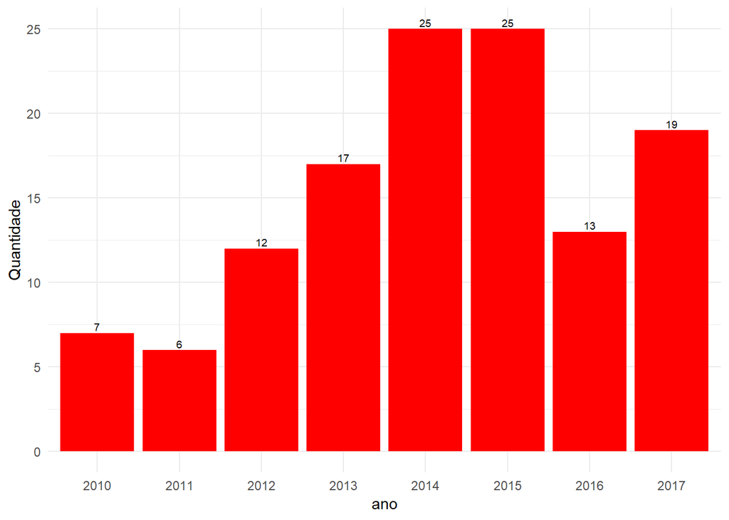

```r
unb.adv.biomed.df %>%
group_by(ano) %>%
summarise(Quantidade = n()) %>%
ggplot(aes(x = ano, y = Quantidade)) +
geom_bar(position = "stack",stat = "identity", fill = "red")+
geom_text(aes(label=Quantidade), vjust=-0.3, size=2.5)+
theme_minimal()
```

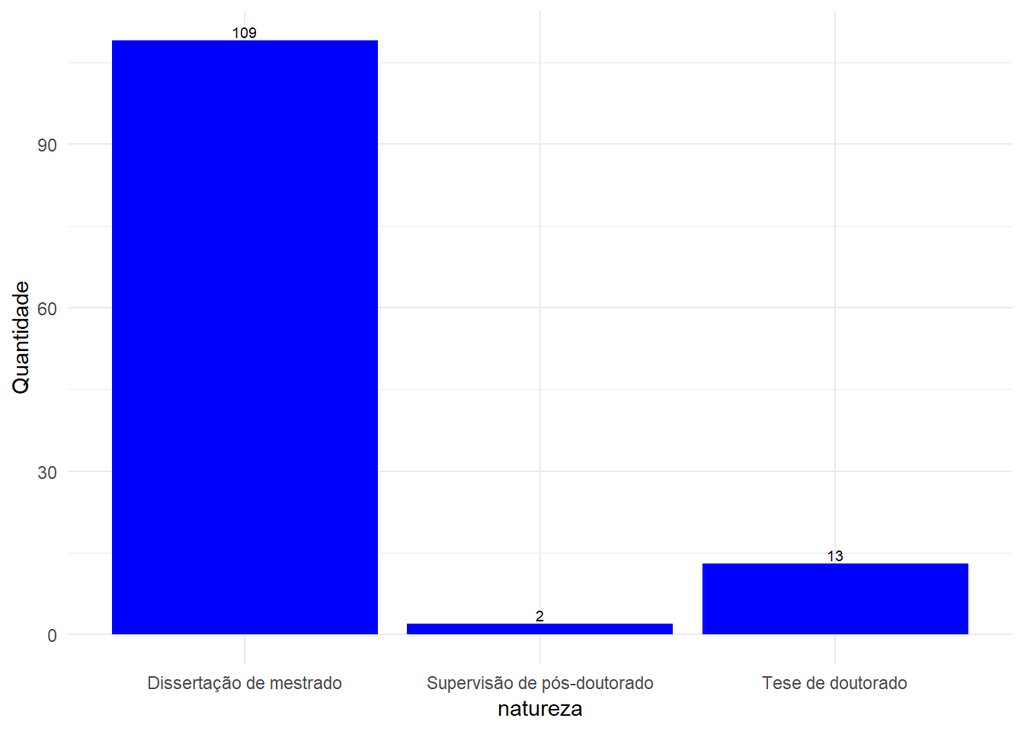

```r
unb.adv.biomed.df %>%
group_by(natureza) %>%
summarise(Quantidade = n()) %>%
ggplot(aes(x = natureza, y = Quantidade)) +
geom_bar(position = "stack",stat = "identity", fill = "blue")+
geom_text(aes(label=Quantidade), vjust=-0.3, size=2.5)+
theme_minimal()
```

Verificando os cursos mais presentes.

```r
cursos_d5
```

```
##
##                              Engenharia Biomédica
##                                                41
##                  Mestrado em Engenharia Biomédica
##                                                26
## Programa de Pós-Graduação em Engenharia Biomédica
##                                                 7
##                               Engenharia Elétrica
##                                                 6
##                                            Física
##                                                 6
```

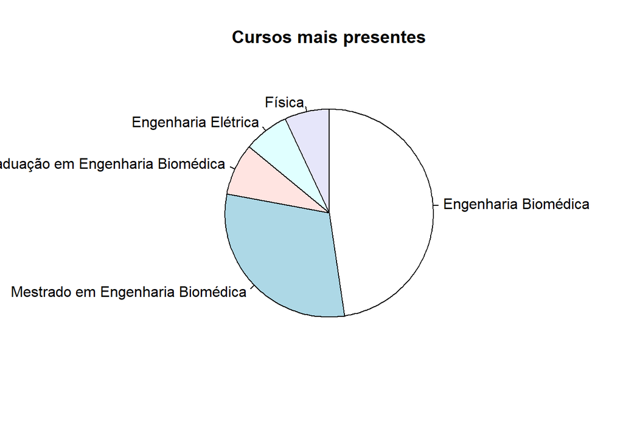

```r
pie(cursos_d5,clockwise=TRUE,main="Cursos mais presentes")
```

Quantos bolsistas tem ?

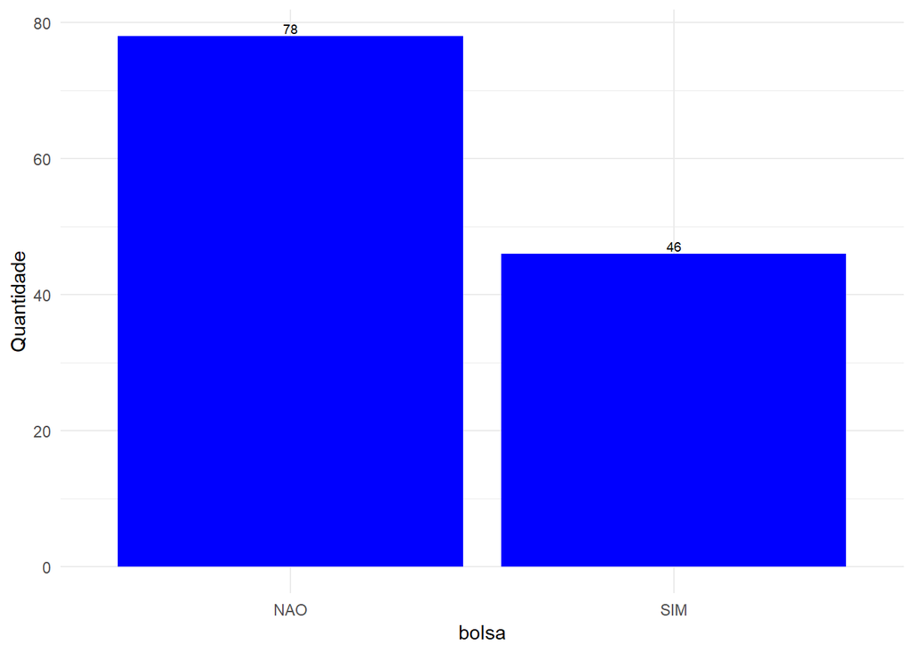

```r
unb.adv.biomed.df %>%
group_by(bolsa) %>%
summarise(Quantidade = n()) %>%
ggplot(aes(x = bolsa, y = Quantidade)) +
geom_bar(position = "stack",stat = "identity", fill = "blue")+
geom_text(aes(label=Quantidade), vjust=-0.3, size=2.5)+
theme_minimal()
```

Assim, estes gráficos permitem verificar alguns aspectos importantes sobre as orientações.

Verificando, agora, o arquivo 279.publication.json, contendo informações sobre as publicações.

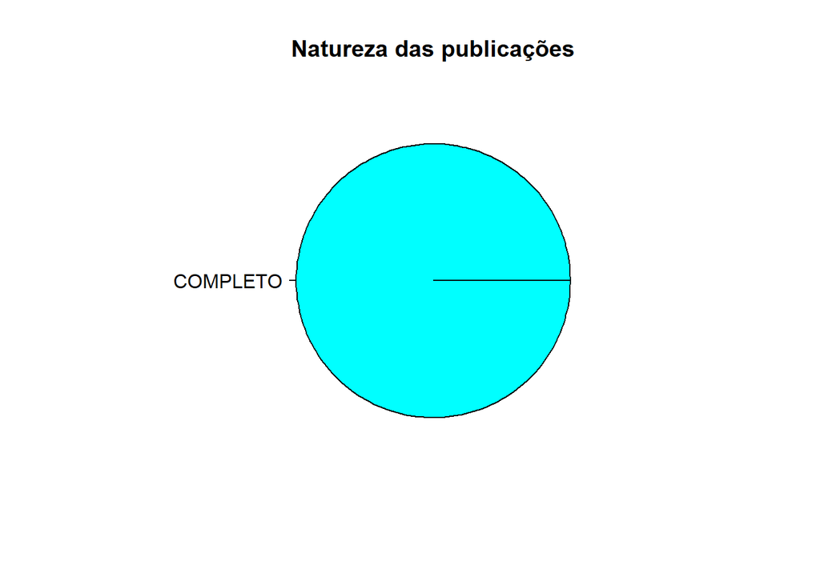

```r
pie(table(unb.pub.biomed.df$natureza),main="Natureza das publicações",col = "cyan")
```

Separando por ano e depois por periódico.

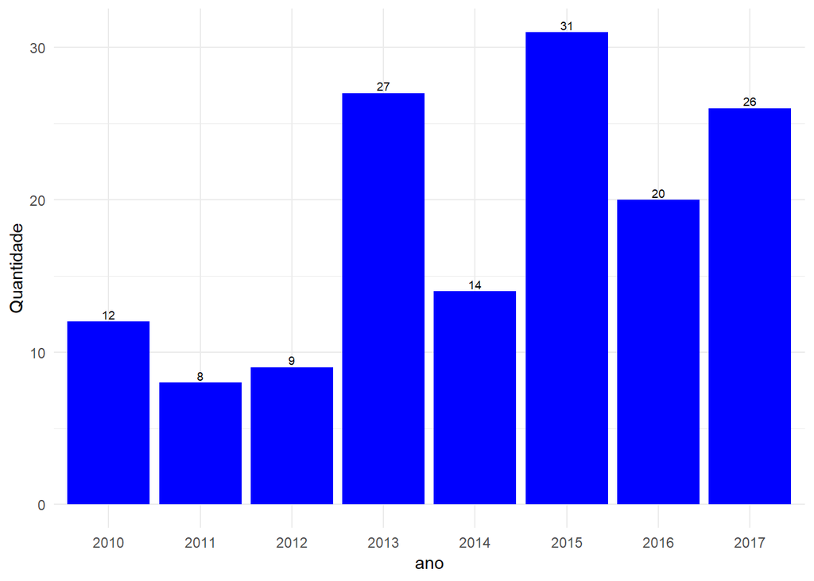

```r
unb.pub.biomed.df %>%
group_by(ano) %>%
summarise(Quantidade = n()) %>%
ggplot(aes(x = ano, y = Quantidade)) +
geom_bar(position = "stack",stat = "identity", fill = "blue")+
geom_text(aes(label=Quantidade), vjust=-0.3, size=2.5)+
theme_minimal()
```

```r
d <- table(unb.pub.biomed.df$periodico)
head(sort(d,decreasing = TRUE),n=5)
```

```
##
##         Revista Brasileira de Engenharia Biomédica (Impresso)
##                                                             7
## Global Journal of Engineering Science and Research Management
##                                                             6
##                        Biomedical Engineering Online (Online)
##                                                             4
##               Revista Brasileira de Ensino de Física (Online)
##                                                             4
##           Revista Brasileira de Inovação Tecnologica em Saúde
##                                                             4
```

Mostrando os autores que mais participaram de publicações.

```r
head(sort(table(toupper(unlist(strsplit(unb.pub.biomed.df$autores,";")))),decreasing = TRUE),n=10)
```

```
##
##                          AMORIM, R. G. G.
##                                        17
##                          AMORIM, R. G. G.
##                                        16
##                       MARÃES, V. R. F. S.
##                                        14
##                             BRASIL, L. M.
##                                         7
##                       MARÃES, V. R. F. S.
##                                         7
##                              SILVA, W. B.
##                                         7
##              GOMES, MARÍLIA MIRANDA FORTE
##                                         7
## ROSA, SUÉLIA DE SIQUEIRA RODRIGUES FLEURY
##                                         7
##                           DA ROCHA, A. F.
##                                         6
##              GOMES, MARÍLIA MIRANDA FORTE
##                                         6
```

Assim, vemos que há algumas incoeráncia neste dado acima, isto se dá pela falta de uniformidade.

Analisando o arquivo 279.profile.json.

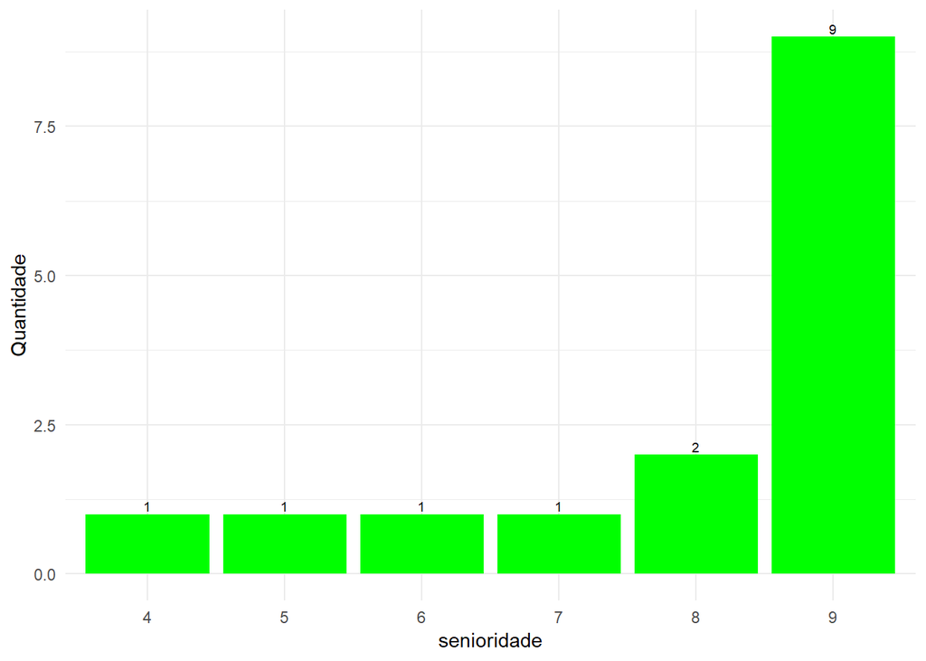

```r
unb.prof.biomed.df %>%
group_by(senioridade) %>%
summarise(Quantidade = n()) %>%
ggplot(aes(x = senioridade, y = Quantidade)) +
geom_bar(position = "stack",stat = "identity", fill = "green")+
geom_text(aes(label=Quantidade), vjust=-0.3, size=2.5)+
theme_minimal()
```

Analisando quandidade de orientações concluídas no doutorado por professor.

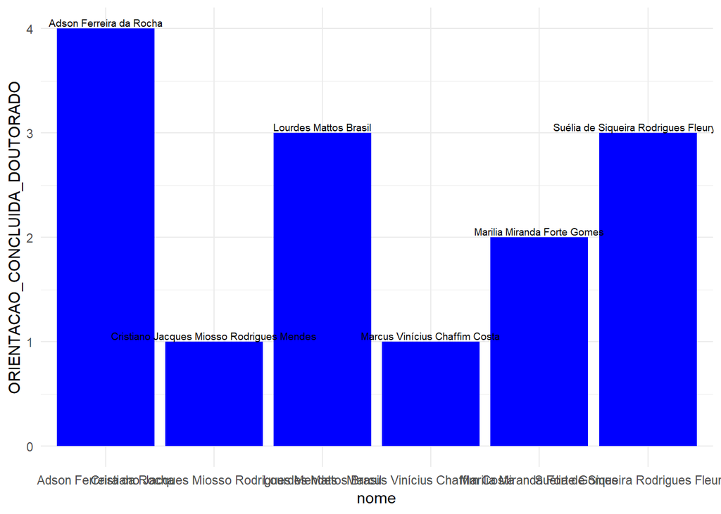

```r
unb.prof.biomed.df %>%
group_by(nome) %>%
filter(!is.na(ORIENTACAO_CONCLUIDA_DOUTORADO ))%>%
ggplot(aes(x = nome, y = ORIENTACAO_CONCLUIDA_DOUTORADO)) +
geom_bar(position = "stack",stat = "identity", fill = "blue")+
geom_text(aes(label=nome), vjust=-0.3, size=2.5)+
theme_minimal()
```

Analisando quandidade de orientações concluídas no mestrado por professor.

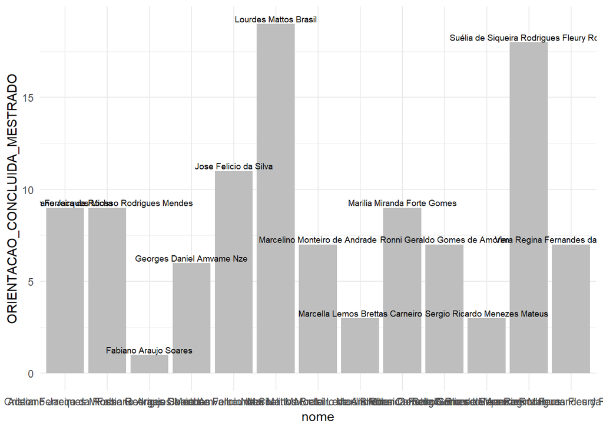

```r
unb.prof.biomed.df %>%
group_by(nome) %>%
filter(!is.na(ORIENTACAO_CONCLUIDA_MESTRADO ))%>%
ggplot(aes(x = nome, y = ORIENTACAO_CONCLUIDA_MESTRADO)) +
geom_bar(position = "stack",stat = "identity", fill = "gray")+
geom_text(aes(label=nome), vjust=-0.3, size=2.5)+
theme_minimal()
```

Analisando quandidade de orientações concluídas no pós-doutorado por professor.

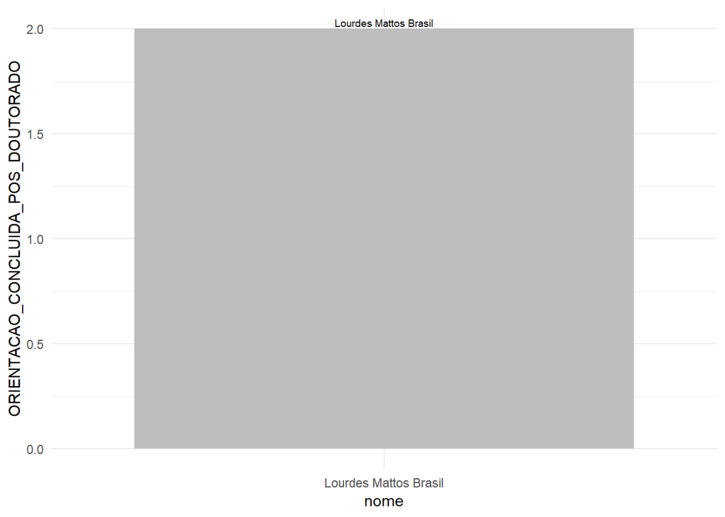

```r
unb.prof.biomed.df %>%
group_by(nome) %>%
filter(!is.na(ORIENTACAO_CONCLUIDA_POS_DOUTORADO))%>%
ggplot(aes(x = nome, y = ORIENTACAO_CONCLUIDA_POS_DOUTORADO)) +
geom_bar(position = "stack",stat = "identity", fill = "gray")+
geom_text(aes(label=nome), vjust=-0.3, size=2.5)+
theme_minimal()
```

Analisando quandidade de orientações concluídas em outros tipos por professor.

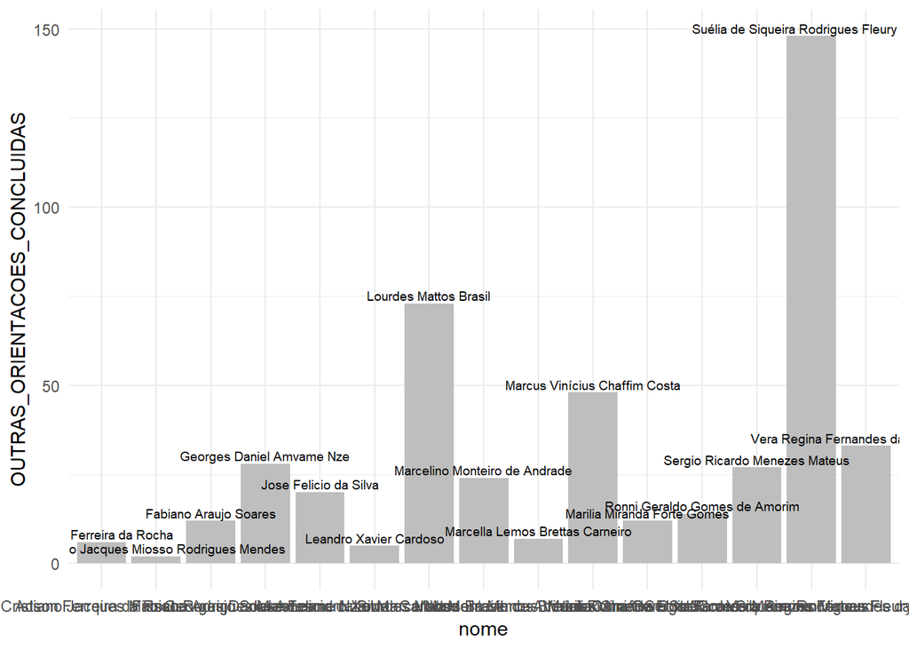

```r
unb.prof.biomed.df %>%
group_by(nome) %>%
filter(!is.na(OUTRAS_ORIENTACOES_CONCLUIDAS))%>%
ggplot(aes(x = nome, y = OUTRAS_ORIENTACOES_CONCLUIDAS)) +
geom_bar(position = "stack",stat = "identity", fill = "gray")+
geom_text(aes(label=nome), vjust=-0.3, size=2.5)+
theme_minimal()
```

Analisando quandidade de eventos ido por professor.

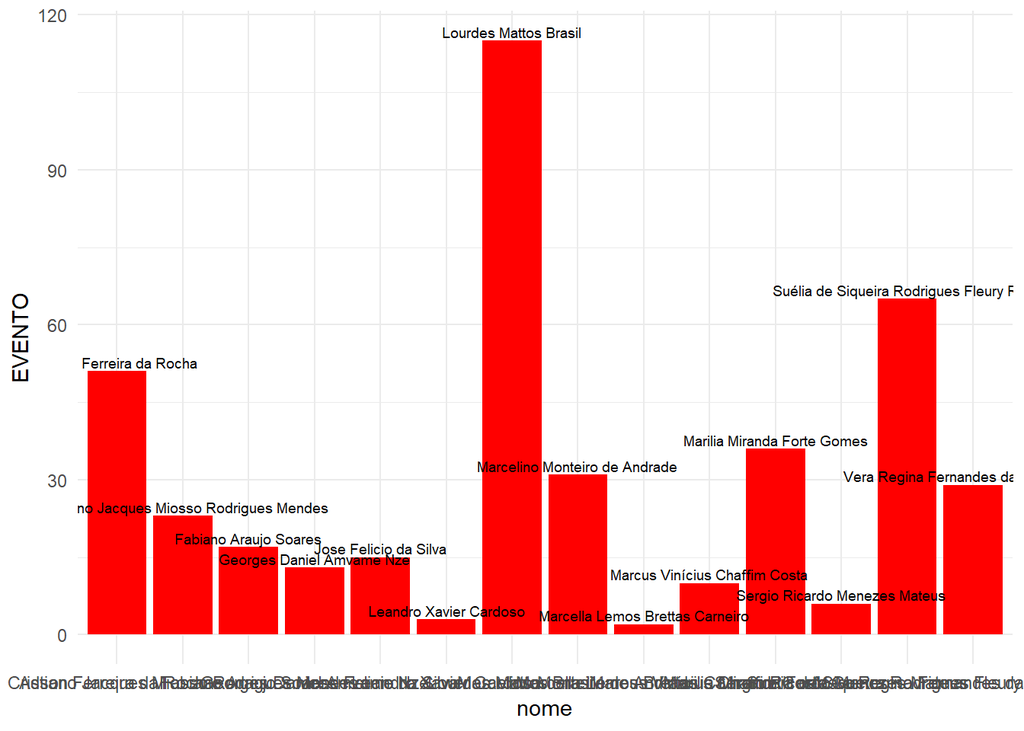

```r
unb.prof.biomed.df %>%
group_by(nome) %>%
filter(!is.na(EVENTO))%>%
ggplot(aes(x = nome, y = EVENTO)) +
geom_bar(position = "stack",stat = "identity", fill = "red")+
geom_text(aes(label=nome), vjust=-0.3, size=2.5)+
theme_minimal()
```

Analisando quandidade de periódicos por professor.

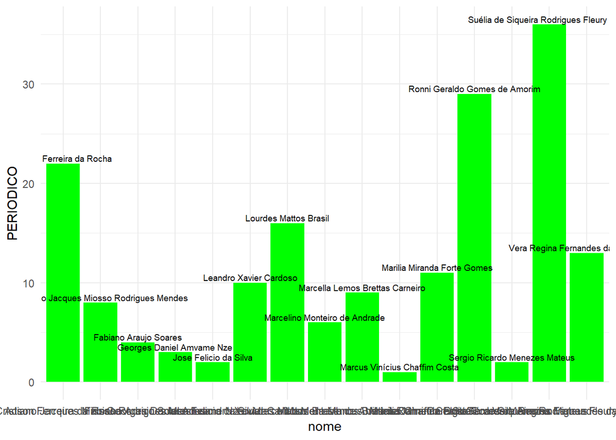

```r
unb.prof.biomed.df %>%
group_by(nome) %>%
filter(!is.na(PERIODICO))%>%
ggplot(aes(x = nome, y = PERIODICO)) +
geom_bar(position = "stack",stat = "identity", fill = "green")+
geom_text(aes(label=nome), vjust=-0.3, size=2.5)+
theme_minimal()
```

Analisando quandidade de livro por professor.

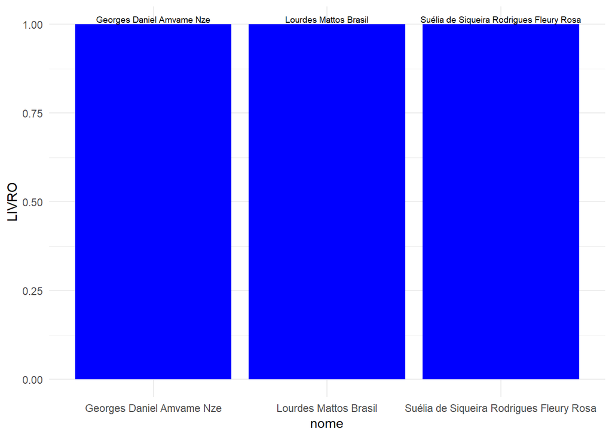

```r
unb.prof.biomed.df %>%
group_by(nome) %>%
filter(!is.na(LIVRO))%>%
ggplot(aes(x = nome, y = LIVRO)) +
geom_bar(position = "stack",stat = "identity", fill = "blue")+
geom_text(aes(label=nome), vjust=-0.3, size=2.5)+
theme_minimal()
```

Analisando quandidade de texto em jornais por professor.

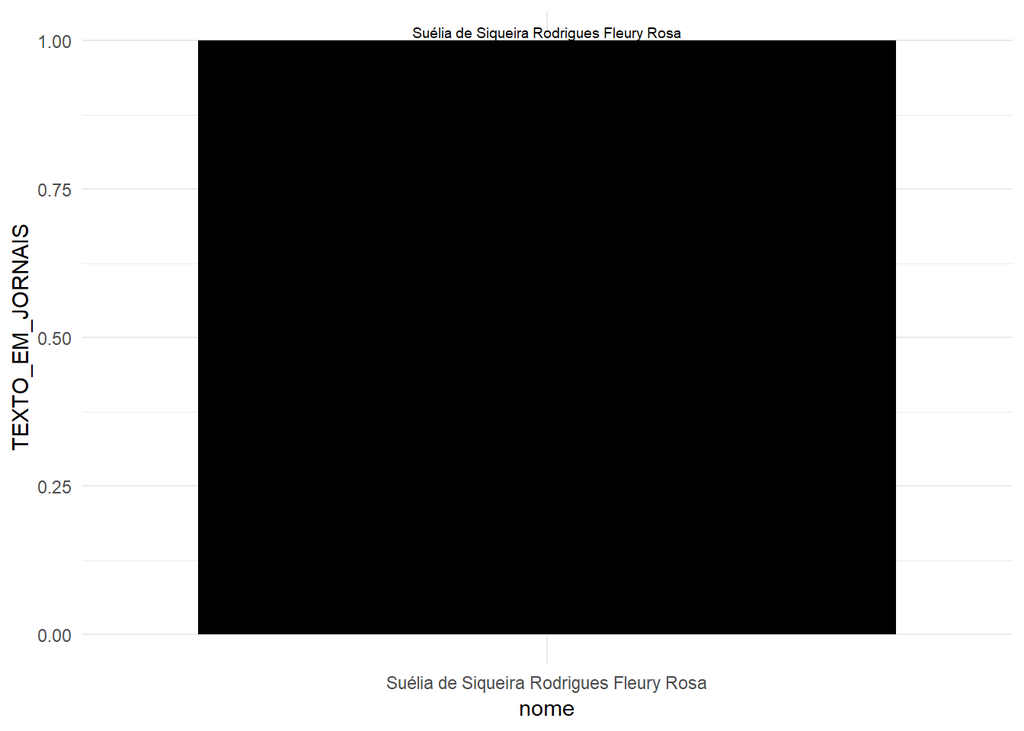

```r
unb.prof.biomed.df %>%
group_by(nome) %>%
filter(!is.na(TEXTO_EM_JORNAIS))%>%
ggplot(aes(x = nome, y = TEXTO_EM_JORNAIS)) +
geom_bar(position = "stack",stat = "identity", fill = "black")+
geom_text(aes(label=nome), vjust=-0.3, size=2.5)+
theme_minimal()
```

Analisando quantidade de professor por major área e posteriormente o área pós-graduação.

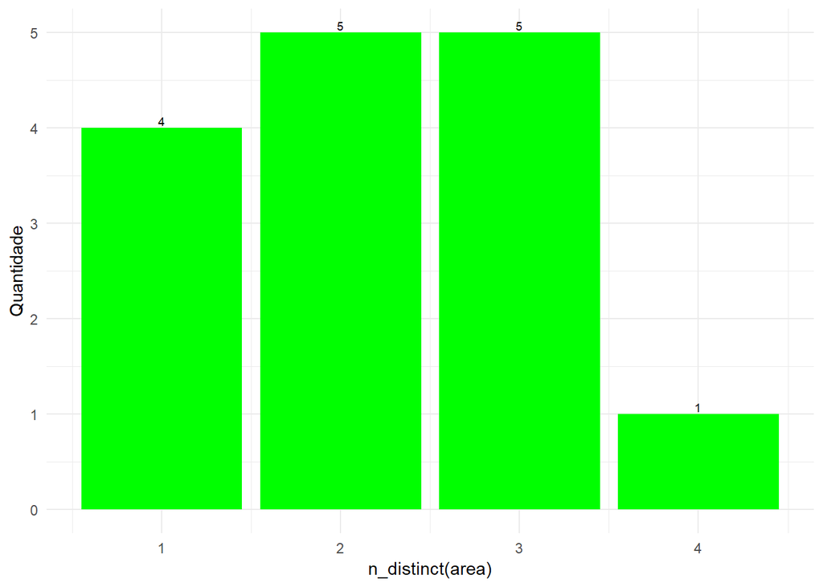

```r
unb.prof.biomed.df %>%
group_by(`n_distinct(area)`) %>%
summarise(Quantidade = n()) %>%
ggplot(aes(x = `n_distinct(area)`, y = Quantidade)) +
geom_bar(position = "stack",stat = "identity", fill = "green")+
geom_text(aes(label=Quantidade), vjust=-0.3, size=2.5)+
theme_minimal()
```

Analisando quantidade de professor por major área e posteriormente o área pós-graduação.

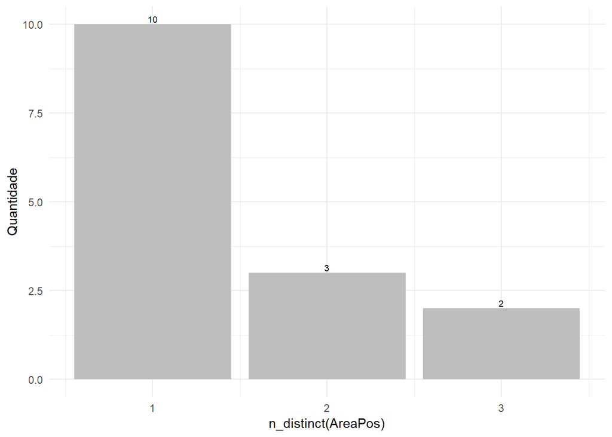

```r
unb.prof.biomed.df %>%
group_by(`n_distinct(AreaPos)`) %>%
summarise(Quantidade = n()) %>%
ggplot(aes(x = `n_distinct(AreaPos)`, y = Quantidade)) +
geom_bar(position = "stack",stat = "identity", fill = "grey")+
geom_text(aes(label=Quantidade), vjust=-0.3, size=2.5)+
theme_minimal()
```

##### Grafos de engenharia biomédica

```r
unb.graph.biomed$links$source
```

```
##  [1] "0201204222182378" "0201204222182378" "0535100751136568"
##  [4] "0535100751136568" "0535100751136568" "0535100751136568"
##  [7] "0535100751136568" "0535100751136568" "0535100751136568"
## [10] "1141716826787805" "1141716826787805" "1141716826787805"
## [13] "1141716826787805" "1141716826787805" "1141716826787805"
## [16] "1154673226500318" "1154673226500318" "1154673226500318"
## [19] "1524924375222848" "2957228356035337" "4739013535126469"
## [22] "4739013535126469" "4739013535126469" "5330755818114960"
## [25] "5810353896294133" "5810353896294133" "7294738832905991"
## [28] "9169095482512290"
```

```r
unb.graph.biomed$links$target
```

```
##  [1] "5810353896294133" "9190489069187153" "1141716826787805"
##  [4] "1154673226500318" "4739013535126469" "5330755818114960"
##  [7] "5810353896294133" "9169095482512290" "9190489069187153"
## [10] "1154673226500318" "2957228356035337" "4739013535126469"
## [13] "5330755818114960" "5928104758017036" "9190489069187153"
## [16] "2957228356035337" "5330755818114960" "9190489069187153"
## [19] "5810353896294133" "9190489069187153" "5330755818114960"
## [22] "5810353896294133" "9190489069187153" "9190489069187153"
## [25] "9169095482512290" "9190489069187153" "9190489069187153"
## [28] "9190489069187153"
```

```r
list_biomed <- c(rbind(unb.graph.biomed$links$source,unb.graph.biomed$links$target))
list_biomed
```

```
##  [1] "0201204222182378" "5810353896294133" "0201204222182378"
##  [4] "9190489069187153" "0535100751136568" "1141716826787805"
##  [7] "0535100751136568" "1154673226500318" "0535100751136568"
## [10] "4739013535126469" "0535100751136568" "5330755818114960"
## [13] "0535100751136568" "5810353896294133" "0535100751136568"
## [16] "9169095482512290" "0535100751136568" "9190489069187153"
## [19] "1141716826787805" "1154673226500318" "1141716826787805"
## [22] "2957228356035337" "1141716826787805" "4739013535126469"
## [25] "1141716826787805" "5330755818114960" "1141716826787805"
## [28] "5928104758017036" "1141716826787805" "9190489069187153"
## [31] "1154673226500318" "2957228356035337" "1154673226500318"
## [34] "5330755818114960" "1154673226500318" "9190489069187153"
## [37] "1524924375222848" "5810353896294133" "2957228356035337"
## [40] "9190489069187153" "4739013535126469" "5330755818114960"
## [43] "4739013535126469" "5810353896294133" "4739013535126469"
## [46] "9190489069187153" "5330755818114960" "9190489069187153"
## [49] "5810353896294133" "9169095482512290" "5810353896294133"
## [52] "9190489069187153" "7294738832905991" "9190489069187153"
## [55] "9169095482512290" "9190489069187153"
```

```r
g_biomed<-graph(list_biomed, directed=TRUE)
g_biomed[ 1:length(g_biomed) ]
```

```
## 10 x 13 sparse Matrix of class "dgCMatrix"
```

```
##    [[ suppressing 13 column names '0201204222182378', '5810353896294133', '9190489069187153' ... ]]
```

```
##
## 0201204222182378 . 1 1 . . . . . . . . . .
## 5810353896294133 . . 1 . . . . . 1 . . . .
## 9190489069187153 . . . . . . . . . . . . .
## 0535100751136568 . 1 1 . 1 1 1 1 1 . . . .
## 1141716826787805 . . 1 . . 1 1 1 . 1 1 . .
## 1154673226500318 . . 1 . . . . 1 . 1 . . .
## 4739013535126469 . 1 1 . . . . 1 . . . . .
## 5330755818114960 . . 1 . . . . . . . . . .
## 9169095482512290 . . 1 . . . . . . . . . .
## 2957228356035337 . . 1 . . . . . . . . . .
```

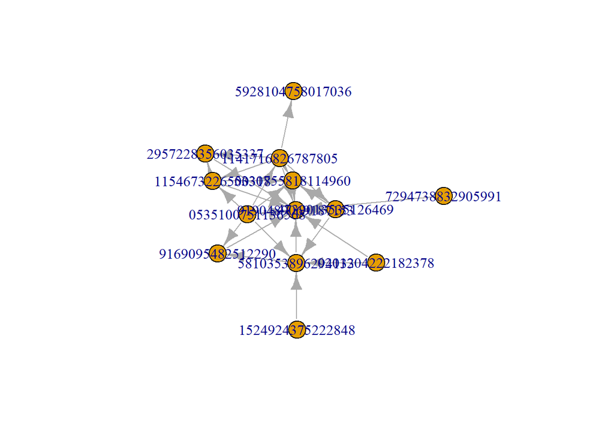

```r
plot(g_biomed)
```

Assim podemos ver algumas relações entre os professores. Abaixo segue o id do professor e seu nome loga em seguida.

```r
c(rbind(unb.graph.biomed$nodes$id,unb.graph.biomed$nodes$properties$name))
```

```
##  [1] "0201204222182378"
##  [2] "Leandro Xavier Cardoso"
##  [3] "0535100751136568"
##  [4] "Cristiano Jacques Miosso Rodrigues Mendes"
##  [5] "1141716826787805"
##  [6] "Adson Ferreira da Rocha"
##  [7] "1154673226500318"
##  [8] "Suélia de Siqueira Rodrigues Fleury Rosa"
##  [9] "1524924375222848"
## [10] "Marcus Vinícius Chaffim Costa"
## [11] "2957228356035337"
## [12] "Jose Felicio da Silva"
## [13] "4086384842130773"
## [14] "Ronni Geraldo Gomes de Amorim"
## [15] "4739013535126469"
## [16] "Marcelino Monteiro de Andrade"
## [17] "4839052902231824"
## [18] "Marcella Lemos Brettas Carneiro"
## [19] "5330755818114960"
## [20] "Fabiano Araujo Soares"
## [21] "5810353896294133"
## [22] "Georges Daniel Amvame Nze"
## [23] "5928104758017036"
## [24] "Sergio Ricardo Menezes Mateus"
## [25] "7294738832905991"
## [26] "Vera Regina Fernandes da Silva Marães"
## [27] "9169095482512290"
## [28] "Marilia Miranda Forte Gomes"
## [29] "9190489069187153"
## [30] "Lourdes Mattos Brasil"
```

# CRISP-DM Fase 6 - **Implatação** (*deployment*)

No caso deste presente trabalho, é basicamente os scripts desenvolvido ao decorrer do mesmo.

# Conclusão

Ao final deste trabalho, podemos chegar a conclusão que com a “ferramenta” CRISP-DM foi possível realizar uma análise de dados apartir de vários arquivos **JSON**, assim, foi possível perceber como funciona - pelo menos de maneira simplória - a vida de cientista de dados, como se deve preparar os dados, como se deve buscar informações úteis, analisar determinadas informações, plotar gráficos para um efeito mais visual, ver a dificuldade que falta de padronização causa, ainda mais quando se tem os mais diversos arquivos para analisar das mais diversas fontes.

O trabalho usou como base o arquivo disponibilizado pelo professor, no qual continha as explicações de todas as fase do CRISP-DM, seguindo o modelo passado pelo professor, tentou-se ir descorrendo sobre o script em R que se vinha fazendo e correlacionando com alguma fase do CRISP-DM, mas tal divisão não pode ser considerada totalmente fidedigna, haja visto que muitas vezes há mistura de fases e não apenas fases totalmente isoladas, sem influência de outras, procurou-se explicar de maneira simples como se encaixava cada fase.

Por fim, podemos chegar a alguns resultados valorosos ,como por exemplo : as revistas que tem mais publicações advindas da pós-graduação em engenharia biomédica, mas nem tudo são flores, algumas dificuldades vieram em decorrência da falta de uniformidade, porém podemos aprender bastante com este trabalho e nos interar de como começar a fazer análise de dados.